# Tugas Mandiri_MPDW pertemuan 1

## Single Moving Average & Double Moving Average

### Pembagian Data

Pembagian data latih dan data uji dilakukan dengan perbandingan 80% data latih dan 20% data uji.

#### hitung jumlah data

```r
n = nrow(data_sales)
n
```

```
## [1] 100
```

#### tentukan batas 80%

```r
n_train = floor(0.8 * n)
n_train
```

```
## [1] 80
```

#### bagi data

```r
training_ma = data_sales[1:n_train, ]
training_ma
```

```
##          Date Total_Sales
## 1  10/28/2022      238.49
## 2  10/29/2022      204.26
## 3  10/30/2022      207.48
## 4  10/31/2022      250.01
## 5   11/1/2022      236.39
## 6   11/2/2022      286.10
## 7   11/3/2022      225.99
## 8   11/4/2022      214.37
## 9   11/5/2022      229.86
## 10  11/6/2022      203.69
## 11  11/7/2022      225.96
## 12  11/8/2022      240.28
## 13  11/9/2022      244.13
## 14 11/10/2022      235.82
```

[output cut: 66 more lines]

```r
testing_ma  = data_sales[(n_train+1):n, ]
testing_ma
```

```
##          Date Total_Sales
## 81  1/16/2023      220.97
## 82  1/17/2023      229.03
## 83  1/18/2023      270.94
## 84  1/19/2023      269.00
## 85  1/20/2023      246.24
## 86  1/21/2023      206.43
## 87  1/22/2023      218.01
## 88  1/23/2023      229.07
## 89  1/24/2023      237.12
## 90  1/25/2023      239.42
## 91  1/26/2023      235.60
## 92  1/27/2023      209.24
## 93  1/28/2023      214.23
## 94  1/29/2023      244.88
## 95  1/30/2023      252.32
## 96  1/31/2023      231.79
## 97   2/1/2023      251.04
## 98   2/2/2023      232.92
## 99   2/3/2023      222.38
## 100  2/4/2023      197.45
```

#### ubah ke time series

```r
# ubah ke time series
train_ma.ts <- ts(training_ma$Total_Sales)
train_ma.ts
```

```
## Time Series:
## Start = 1
## End = 80
## Frequency = 1
##  [1] 238.49 204.26 207.48 250.01 236.39 286.10 225.99 214.37 229.86 203.69
## [11] 225.96 240.28 244.13 235.82 212.09 204.63 203.58 222.44 235.85 240.90
## [21] 232.62 208.25 212.03 200.45 215.10 242.64 284.72 233.12 215.83 201.86
## [31] 201.34 251.90 273.82 245.99 229.61 208.91 200.66 238.25 219.05 233.44
## [41] 242.68 231.92 250.85 200.26 207.69 214.98 230.87 238.22 229.98 215.29
## [51] 250.35 211.17 261.77 238.16 267.15 231.30 212.65 244.93 203.09 225.51
## [61] 246.27 271.97 233.75 257.89 201.66 238.70 223.33 269.44 239.00 262.22
## [71] 217.28 241.27 212.73 264.38 235.47 247.58 233.36 226.09 200.33 204.08
```

```r
test_ma.ts  <- ts(testing_ma$Total_Sales)
test_ma.ts
```

```
## Time Series:
## Start = 1
## End = 20
## Frequency = 1
##  [1] 220.97 229.03 270.94 269.00 246.24 206.43 218.01 229.07 237.12 239.42
## [11] 235.60 209.24 214.23 244.88 252.32 231.79 251.04 232.92 222.38 197.45
```

Eksplorasi data dilakukan pada keseluruhan data, data latih serta data uji menggunakan plot data deret waktu.

#### Eksplorasi keseluruhan data

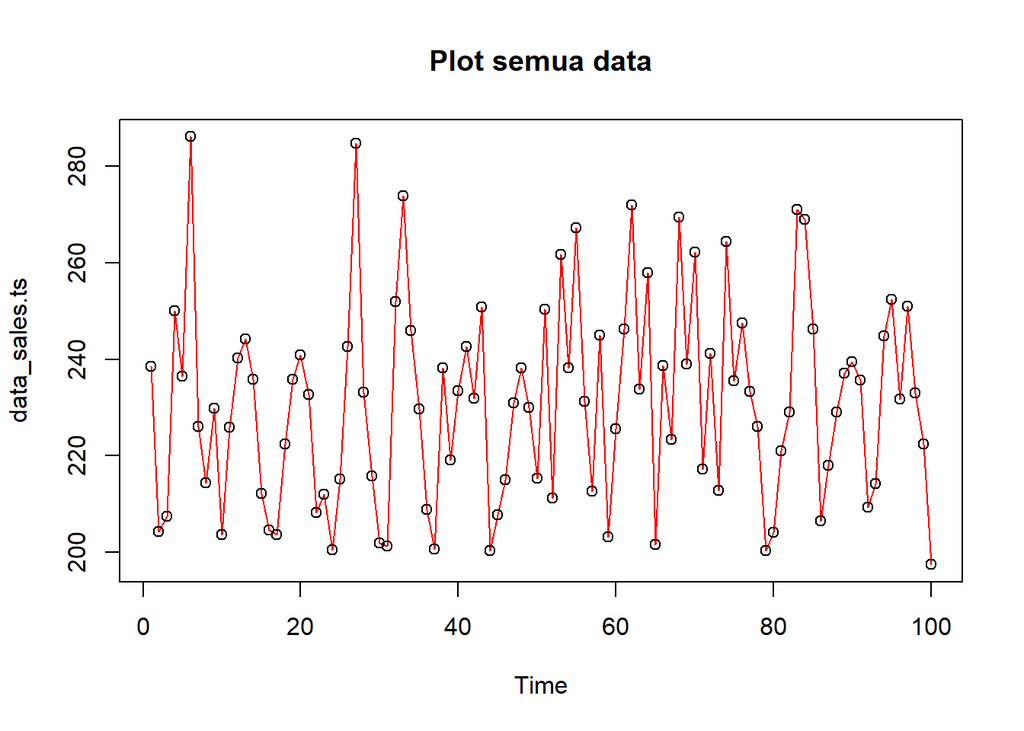

```r
plot(data_sales.ts, col="red",main="Plot semua data")
points(data_sales.ts)
```

#### Eksplorasi data latih

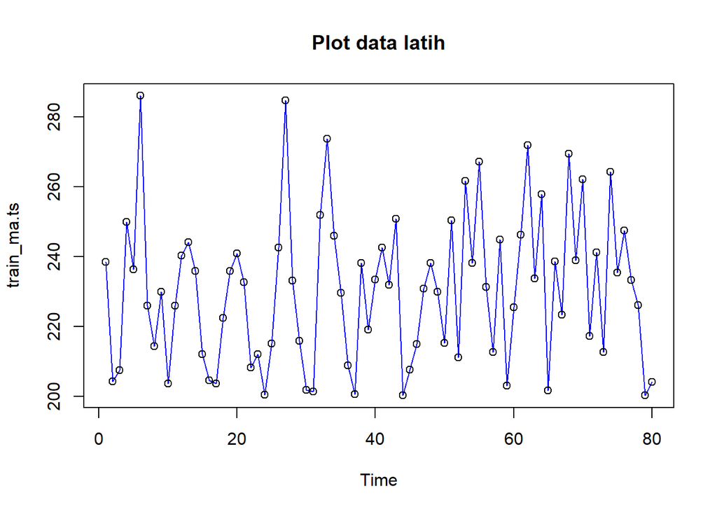

```r
plot(train_ma.ts, col="blue",main="Plot data latih")
points(train_ma.ts)
```

#### Eksplorasi data uji

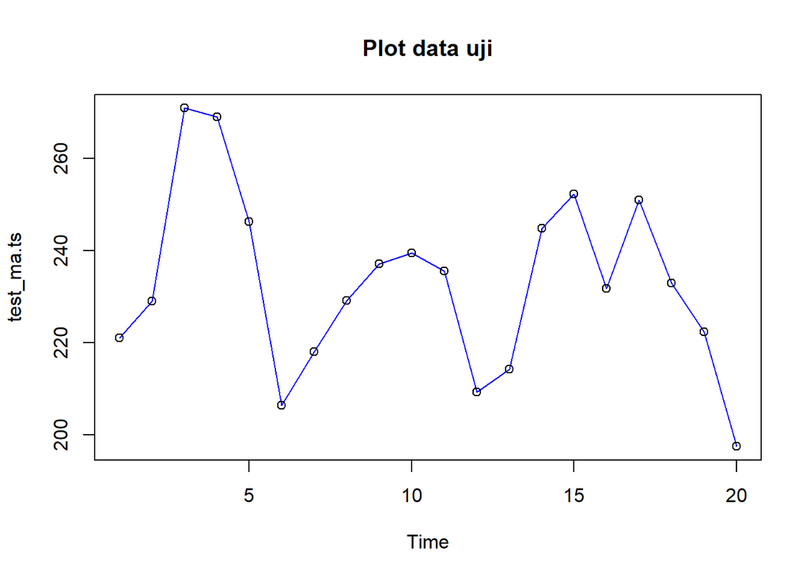

```r
plot(test_ma.ts, col="blue",main="Plot data uji")
points(test_ma.ts)
```

Eksplorasi data juga dapat dilakukan menggunakan package `ggplot2` dengan terlebih dahulu memanggil library *package* `ggplot2`.

```r
library(ggplot2)

# ubah kolom Date jadi format Date
training_ma$Date <- as.Date(training_ma$Date, format = "%m/%d/%Y")
testing_ma$Date  <- as.Date(testing_ma$Date, format = "%m/%d/%Y")

list(training_data = str(training_ma),
testing_data = str(testing_ma))
```

```
## 'data.frame':    80 obs. of  2 variables:
##  $ Date       : Date, format: "2022-10-28" "2022-10-29" ...
##  $ Total_Sales: num  238 204 207 250 236 ...
## 'data.frame':    20 obs. of  2 variables:
##  $ Date       : Date, format: "2023-01-16" "2023-01-17" ...
##  $ Total_Sales: num  221 229 271 269 246 ...
```

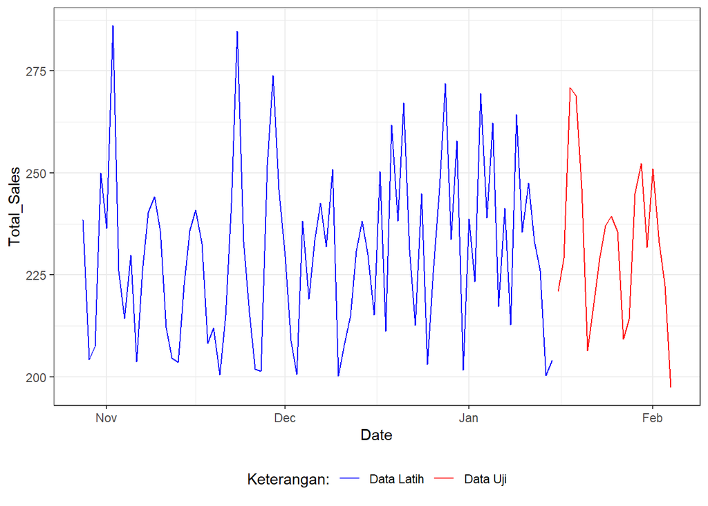

```r
# plot
ggplot() +
  geom_line(data = training_ma, aes(x = Date, y = Total_Sales, col = "Data Latih")) +
  geom_line(data = testing_ma, aes(x = Date, y = Total_Sales, col = "Data Uji")) +
  labs(x = "Date", y = "Total_Sales", color = "Legend") +
   scale_colour_manual(name="Keterangan:", breaks = c("Data Latih", "Data Uji"),
                      values = c("blue", "red")) +
  theme_bw() + theme(legend.position = "bottom",
                     plot.caption = element_text(hjust=0.5, size=12))
```

### Single Moving Average (SMA)

```r
data.sma = SMA(train_ma.ts, n=4)
data.sma
```

```
## Time Series:
## Start = 1
## End = 80
## Frequency = 1
##  [1]       NA       NA       NA 225.0600 224.5350 244.9950 249.6225 240.7125
##  [9] 239.0800 218.4775 218.4700 224.9475 228.5150 236.5475 233.0800 224.1675
## [17] 214.0300 210.6850 216.6250 225.6925 232.9525 229.4050 223.4500 213.3375
## [25] 208.9575 217.5550 235.7275 243.8950 244.0775 233.8825 213.0375 217.7325
## [33] 232.2300 243.2625 250.3300 239.5825 221.2925 219.3575 216.7175 222.8500
## [41] 233.3550 231.7725 239.7225 231.4275 222.6800 218.4450 213.4500 222.9400
## [49] 228.5125 228.5900 233.4600 226.6975 234.6450 240.3625 244.5625 249.5950
## [57] 237.3150 239.0075 222.9925 221.5450 229.9500 236.7100 244.3750 252.4700
## [65] 241.3175 233.0000 230.3950 233.2825 242.6175 248.4975 246.9850 239.9425
## [73] 233.3750 233.9150 238.4625 240.0400 245.1975 235.6250 226.8400 215.9650
```

Data pemulusan pada periode ke-t selanjutnya digunakan sebagai nilai peramalan pada periode ke t+1 sehingga hasil peramalan 1 periode kedepan adalah sebagai berikut.

```r
data.ramal = c(NA,data.sma)
data.ramal #forecast 1 periode ke depan
```

```
##  [1]       NA       NA       NA       NA 225.0600 224.5350 244.9950 249.6225
##  [9] 240.7125 239.0800 218.4775 218.4700 224.9475 228.5150 236.5475 233.0800
## [17] 224.1675 214.0300 210.6850 216.6250 225.6925 232.9525 229.4050 223.4500
## [25] 213.3375 208.9575 217.5550 235.7275 243.8950 244.0775 233.8825 213.0375
## [33] 217.7325 232.2300 243.2625 250.3300 239.5825 221.2925 219.3575 216.7175
## [41] 222.8500 233.3550 231.7725 239.7225 231.4275 222.6800 218.4450 213.4500
## [49] 222.9400 228.5125 228.5900 233.4600 226.6975 234.6450 240.3625 244.5625
## [57] 249.5950 237.3150 239.0075 222.9925 221.5450 229.9500 236.7100 244.3750
## [65] 252.4700 241.3175 233.0000 230.3950 233.2825 242.6175 248.4975 246.9850
## [73] 239.9425 233.3750 233.9150 238.4625 240.0400 245.1975 235.6250 226.8400
## [81] 215.9650
```

Selanjutnya dilakukan peramalan sebanyak 20 periode sesuai dengan jumlah data uji. Pada metode SMA, seluruh hasil peramalan untuk 20 periode ke depan akan memiliki nilai yang sama dengan hasil ramalan satu periode ke depan.

```r
length(data_sales.ts)
```

```
## [1] 100
```

```r
length(data.ramal)
```

```
## [1] 81
```

```r
data.gab = cbind(
  aktual = c(data_sales.ts),
  pemulusan = c(data.sma,rep(NA,20)),
  ramalan = c(data.ramal,rep(data.ramal[length(data.ramal)],19)))

data.gab #forecast 20 periode ke depan
```

```
##        aktual pemulusan  ramalan
##   [1,] 238.49        NA       NA
##   [2,] 204.26        NA       NA
##   [3,] 207.48        NA       NA
##   [4,] 250.01  225.0600       NA
##   [5,] 236.39  224.5350 225.0600
##   [6,] 286.10  244.9950 224.5350
##   [7,] 225.99  249.6225 244.9950
##   [8,] 214.37  240.7125 249.6225
##   [9,] 229.86  239.0800 240.7125
##  [10,] 203.69  218.4775 239.0800
##  [11,] 225.96  218.4700 218.4775
##  [12,] 240.28  224.9475 218.4700
##  [13,] 244.13  228.5150 224.9475
##  [14,] 235.82  236.5475 228.5150
```

[output cut: 86 more lines]

Adapun plot data deret waktu dari hasil peramalan yang dilakukan adalah sebagai berikut.

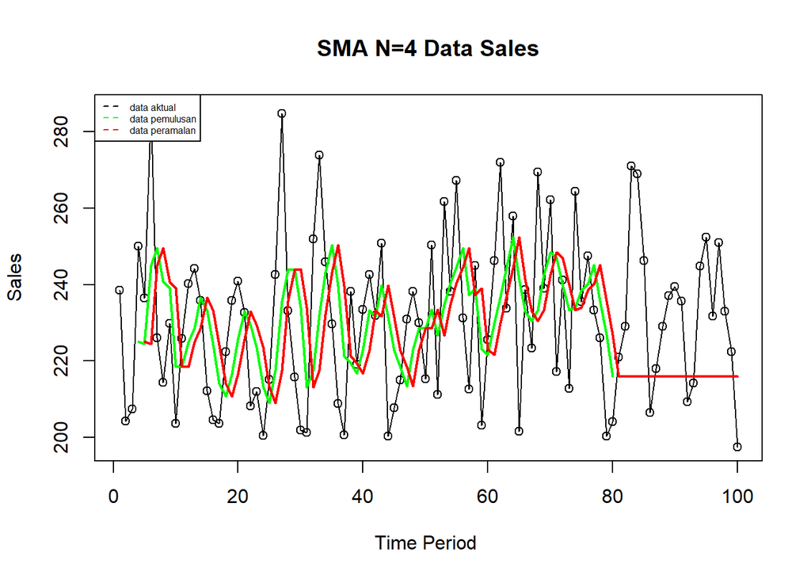

```r
ts.plot(data_sales.ts, xlab="Time Period ", ylab="Sales", main= "SMA N=4 Data Sales")
points(data_sales.ts)
lines(data.gab[,2],col="green",lwd=2)
lines(data.gab[,3],col="red",lwd=2)
legend("topleft",c("data aktual","data pemulusan","data peramalan"), lty=8, col=c("black","green","red"), cex=0.5)
```

Selanjutnya perhitungan akurasi dilakukan dengan ukuran akurasi *Sum Squares Error* **(SSE), *Mean*** *Square Error* **(MSE) dan *Mean Absolute Percentage Error* (MAPE).** Perhitungan akurasi dilakukan baik pada data latih maupun pada data uji.

$$SSE = \sum_{t=1}^{n} (y_t - \hat{y}_t)^2$$
$$MSE = \frac{1}{n} \sum_{t=1}^{n} (y_t - \hat{y}_t)^2$$
$$MAPE = \frac{1}{n} \sum_{t=1}^{n} \left|\frac{y_t -
\hat{y}_t}{y_t}\right| * 100$$

```r
#Menghitung nilai keakuratan data latih
error_train.sma = train_ma.ts-data.ramal[1:length(train_ma.ts)]

SSE_train.sma = sum(error_train.sma[5:length(train_ma.ts)]^2)
MSE_train.sma = mean(error_train.sma[5:length(train_ma.ts)]^2)
MAPE_train.sma = mean(abs((error_train.sma[5:length(train_ma.ts)]/train_ma.ts[5:length(train_ma.ts)])*100))

akurasi_train.sma <- matrix(c(SSE_train.sma, MSE_train.sma, MAPE_train.sma))
row.names(akurasi_train.sma)<- c("SSE", "MSE", "MAPE")
colnames(akurasi_train.sma) <- c("Akurasi m = 4")
akurasi_train.sma
```

```
##      Akurasi m = 4
## SSE   52490.920125
## MSE     690.670002
## MAPE      9.469714
```

Dalam hal ini nilai MAPE data latih pada metode pemulusan SMA sekitar 9%, nilai ini dapat dikategorikan sebagai nilai akurasi yang sangat baik. Selanjutnya dilakukan perhitungan nilai MAPE data uji pada metode pemulusan SMA.

```r
View(data.gab)
```

```r
error_test.sma = test_ma.ts-data.gab[81:100,3]

SSE_test.sma = sum(error_test.sma^2)
MSE_test.sma = mean(error_test.sma^2)
MAPE_test.sma = mean(abs((error_test.sma/test_ma.ts*100)))

akurasi_test.sma <- matrix(c(SSE_test.sma, MSE_test.sma, MAPE_test.sma))
row.names(akurasi_test.sma)<- c("SSE", "MSE", "MAPE")
colnames(akurasi_test.sma) <- c("Akurasi m = 4")
akurasi_test.sma
```

```
##      Akurasi m = 4
## SSE   12955.440100
## MSE     647.772005
## MAPE      8.459052
```

```r
# Hitung error data uji
error_test.sma = test_ma.ts - data.gab[81:100, 3]

# SSE, MSE, MAPE untuk data uji
SSE_test.sma = sum(error_test.sma^2)
MSE_test.sma = mean(error_test.sma^2)
MAPE_test.sma = mean(abs((error_test.sma/test_ma.ts)*100))

# Matriks akurasi data uji
akurasi_test.sma = matrix(c(SSE_test.sma, MSE_test.sma, MAPE_test.sma))
row.names(akurasi_test.sma) = c("SSE", "MSE", "MAPE")
colnames(akurasi_test.sma) = c("Akurasi m = 4 (Data Uji)")

akurasi_test.sma
```

```
##      Akurasi m = 4 (Data Uji)
## SSE              12955.440100
## MSE                647.772005
## MAPE                 8.459052
```

Perhitungan akurasi menggunakan data latih menghasilkan nilai MAPE yang kurang dari 10% sehingga nilai akurasi ini dapat dikategorikan sebagai sangat baik.

### Double Moving Average (DMA)

Metode pemulusan **Double Moving Average (DMA)** pada dasarnya mirip dengan SMA. Namun demikian, metode ini lebih cocok **digunakan untuk pola data trend**. Proses pemulusan dengan rata rata dalam metode ini dilakukan sebanyak 2 kali.

- **Tahap I:**

$$S_{1,t} = \frac{1}{m} \sum_{i=t-m+1}^{t} X_i$$

- **Tahap II:**

$$S_{2,t} = \frac{1}{m} \sum_{i=t-m+1}^{t} S_{1,i}$$

Forecast $h$ langkah ke depan dihitung dengan:

$$F_{2,t,t+h} = A_t + B_t \,(h)$$

dengan komponen level ($A_t$) dan tren ($B_t$):

$$A_t = 2S_{1,t} - S_{2,t}
\qquad\text{dan}\qquad
B_t = \frac{2}{m-1}\,\big(S_{1,t} - S_{2,t}\big)$$

```r
dma = SMA(data.sma, n = 4)
At = 2*data.sma - dma
Bt = 2/(4-1)*(data.sma - dma)
data.dma = At+Bt
data.ramal2 = c(NA, data.dma)

t = 1:24
f = c()

for (i in t) {
  f[i] = At[length(At)] + Bt[length(Bt)]*(i)
}

data.gab2 <- cbind(aktual = c(data_sales.ts),
                   pemulusan1 = c(data.sma,rep(NA,24)),
                   pemulusan2 = c(dma, rep(NA,24)),
                   At = c(At, rep(NA,24)),
                   Bt = c(Bt,rep(NA,24)),
                   ramalan = c(data.ramal2, f[-1]))
data.gab2
```

```
##        aktual pemulusan1 pemulusan2       At          Bt    ramalan
##   [1,] 238.49         NA         NA       NA          NA         NA
##   [2,] 204.26         NA         NA       NA          NA         NA
##   [3,] 207.48         NA         NA       NA          NA         NA
##   [4,] 250.01   225.0600         NA       NA          NA         NA
##   [5,] 236.39   224.5350         NA       NA          NA         NA
##   [6,] 286.10   244.9950         NA       NA          NA         NA
##   [7,] 225.99   249.6225   236.0531 263.1919   9.0462500         NA
##   [8,] 214.37   240.7125   239.9663 241.4588   0.4975000 272.238125
##   [9,] 229.86   239.0800   243.6025 234.5575  -3.0150000 241.956250
##  [10,] 203.69   218.4775   236.9731 199.9819 -12.3304167 231.542500
##  [11,] 225.96   218.4700   229.1850 207.7550  -7.1433333 187.651458
##  [12,] 240.28   224.9475   225.2437 224.6513  -0.1975000 200.611667
##  [13,] 244.13   228.5150   222.6025 234.4275   3.9416667 224.453750
##  [14,] 235.82   236.5475   227.1200 245.9750   6.2850000 238.369167
```

[output cut: 90 more lines]

Hasil pemulusan menggunakan metode DMA divisualisasikan sebagai berikut

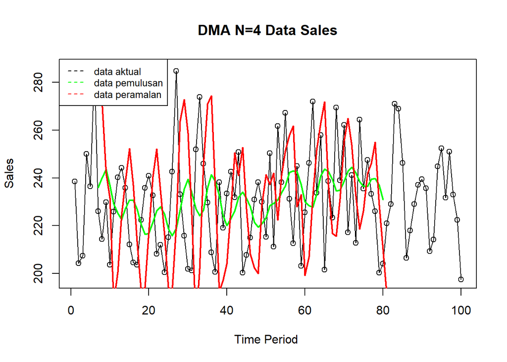

```r
ts.plot(data_sales.ts, xlab="Time Period ", ylab="Sales", main= "DMA N=4 Data Sales")
points(data_sales.ts)
lines(data.gab2[,3],col="green",lwd=2)
lines(data.gab2[,6],col="red",lwd=2)
legend("topleft",c("data aktual","data pemulusan","data peramalan"), lty=8, col=c("black","green","red"), cex=0.8)
```

Selanjutnya perhitungan akurasi dilakukan baik pada data latih maupun data uji. Perhitungan akurasi dilakukan dengan ukuran akurasi SSE, MSE dan MAPE.

```r
#Menghitung nilai keakuratan data latih
error_train.dma = train_ma.ts-data.ramal2[1:length(train_ma.ts)]

SSE_train.dma = sum(error_train.dma[8:length(train_ma.ts)]^2)
MSE_train.dma = mean(error_train.dma[8:length(train_ma.ts)]^2)
MAPE_train.dma = mean(abs((error_train.dma[8:length(train_ma.ts)]/train_ma.ts[8:length(train_ma.ts)])*100))

akurasi_train.dma <- matrix(c(SSE_train.dma, MSE_train.dma, MAPE_train.dma))
row.names(akurasi_train.dma)<- c("SSE", "MSE", "MAPE")
colnames(akurasi_train.dma) <- c("Akurasi m = 4")
akurasi_train.dma
```

```
##      Akurasi m = 4
## SSE    85657.82897
## MSE     1173.39492
## MAPE      12.54363
```

Perhitungan akurasi pada data latih menggunakan nilai MAPE menghasilkan nilai MAPE 12% yang kurang dari 20% sehingga dikategorikan cukup baik. Selanjutnya, perhitungan nilai akurasi dilakukan pada data uji.

```r
#Menghitung nilai keakuratan data uji
error_test.dma = test_ma.ts-data.gab2[81:100,6]
SSE_test.dma = sum(error_test.dma^2)
MSE_test.dma = mean(error_test.dma^2)
MAPE_test.dma = mean(abs((error_test.dma/test_ma.ts*100)))

akurasi_test.dma <- matrix(c(SSE_test.dma, MSE_test.dma, MAPE_test.dma))
row.names(akurasi_test.dma)<- c("SSE", "MSE", "MAPE")
colnames(akurasi_test.dma) <- c("Akurasi m = 4")
akurasi_test.dma
```

```
##      Akurasi m = 4
## SSE   434915.29751
## MSE    21745.76488
## MAPE      58.80864
```

## Single Exponential Smoothing & Double Exponential Smoothing

Metode Exponential Smoothing merupakan metode **pemulusan deret waktu dengan memberikan bobot yang menurun secara eksponensial pada data historis,** di mana nilai terbaru mendapat bobot lebih besar dibanding nilai yang lebih lama. Metode ini menggunakan satu atau lebih parameter pemulusan yang secara langsung menentukan besar kecilnya bobot setiap pengamatan. Pemilihan parameter yang tepat akan sangat berpengaruh terhadap hasil ramalan. Secara umum, Exponential Smoothing dibedakan menjadi dua jenis, yaitu model tunggal (single) yang digunakan untuk data tanpa tren maupun musiman, serta model ganda (double) yang mampu menangkap adanya tren pada data.

### Pembagian Data

Pembagian data latih dan data uji dilakukan dengan perbandingan 80% data latih dan 20% data uji.

```r
# jumlah baris data
n = nrow(data_sales)

# hitung batas 80%
n_train = floor(0.8 * n)

# bagi data
training = data_sales[1:n_train, ]
testing  = data_sales[(n_train+1):n, ]

# ubah ke time series
train.ts = ts(training$Total_Sales)
test.ts  = ts(testing$Total_Sales)
```

### Eksplorasi

Eksplorasi dilakukan dengan membuat plot data deret waktu untuk keseluruhan data, data latih, dan data uji.

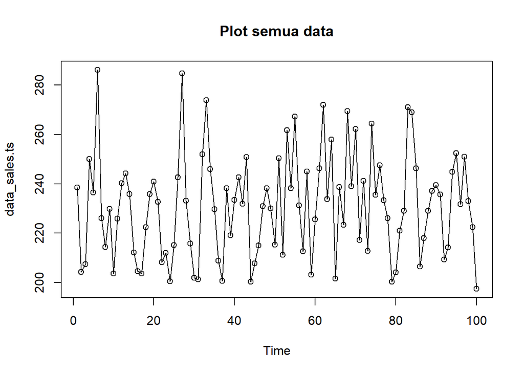

```r
#eksplorasi data
plot(data_sales.ts, col="black",main="Plot semua data")
points(data_sales.ts)
```

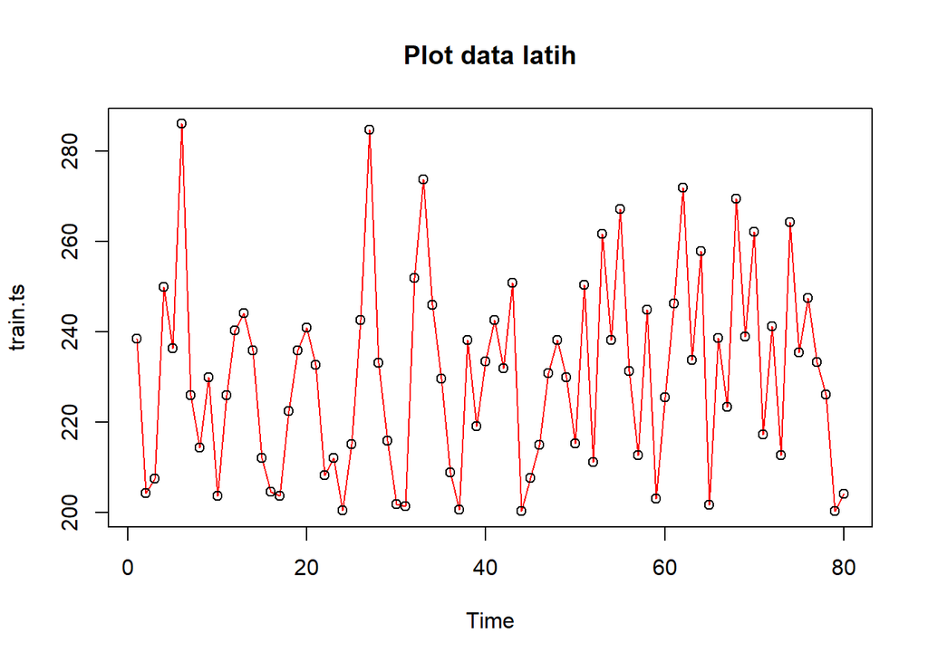

```r
plot(train.ts, col="red",main="Plot data latih")
points(train.ts)
```

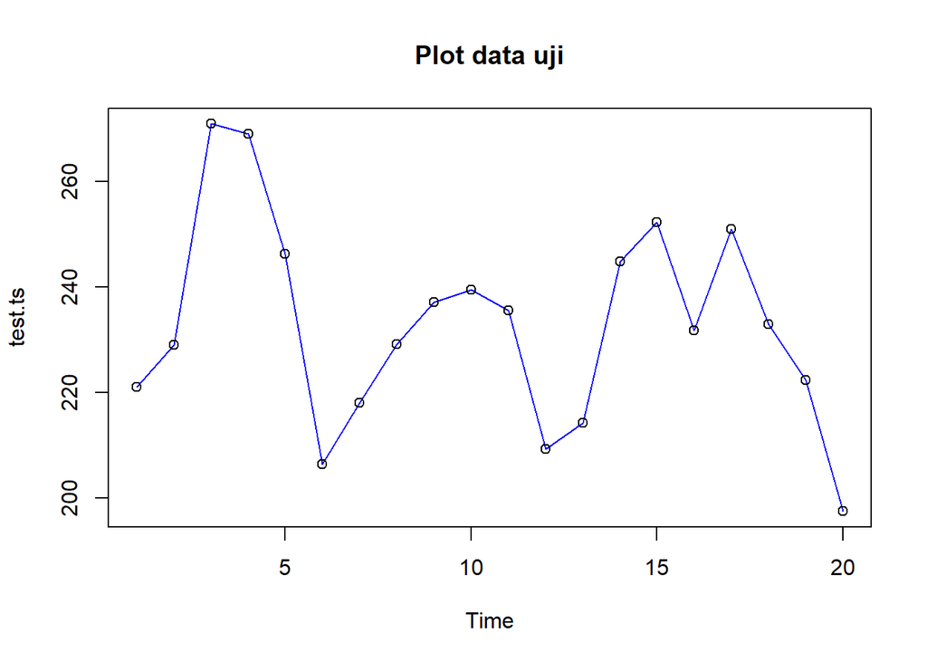

```r
plot(test.ts, col="blue",main="Plot data uji")
points(test.ts)
```

```
## `geom_line()`: Each group consists of only one observation.
## ℹ Do you need to adjust the group aesthetic?
## `geom_line()`: Each group consists of only one observation.
## ℹ Do you need to adjust the group aesthetic?
```

[figure not shown]

```r
#Eksplorasi dengan GGPLOT
library(ggplot2)
ggplot() +
  geom_line(data = training, aes(x = Date, y = Total_Sales, col = "Data Latih")) +
  geom_line(data = testing, aes(x = Date, y = Total_Sales, col = "Data Uji")) +
  labs(x = "Periode Waktu", y = "Membaca", color = "Legend") +
  scale_colour_manual(name="Keterangan:", breaks = c("Data Latih", "Data Uji"),
                      values = c("blue", "red")) +
  theme_bw() + theme(legend.position = "bottom",
                     plot.caption = element_text(hjust=0.5, size=12))
```

## Single Exponential Smoothing

**Single Exponential Smoothing (SES)** adalah metode peramalan deret waktu yang **dikembangkan untuk mengatasi kelemahan Moving Average.** Jika pada Moving Average setiap data periode sebelumnya dianggap memiliki bobot yang sama, maka **SES memberikan bobot yang semakin mengecil secara eksponensial terhadap data lama,** sehingga data terbaru diberi bobot lebih besar.

Single Exponential Smoothing merupakan metode pemulusan yang tepat digunakan untuk data dengan pola stasioner atau konstan.

Nilai pemulusan pada periode ke-t didapat dari persamaan:

$$\tilde{y}_T=\lambda
y_t+(1-\lambda)\tilde{y}_{T-1}$$

Nilai parameter $\lambda$ adalah nilai antara 0 dan 1.

Nilai pemulusan periode ke-t bertindak sebagai nilai ramalan pada periode ke-$(T+\tau)$.

$$\tilde{y}_{T+\tau}(T)=\tilde{y}_T$$

Pemulusan dengan metode SES dapat dilakukan dengan dua fungsi dari *packages* berbeda, yaitu (1) fungsi `ses()` dari *packages* `forecast` dan (2) fungsi `HoltWinters` dari *packages* `stats` .

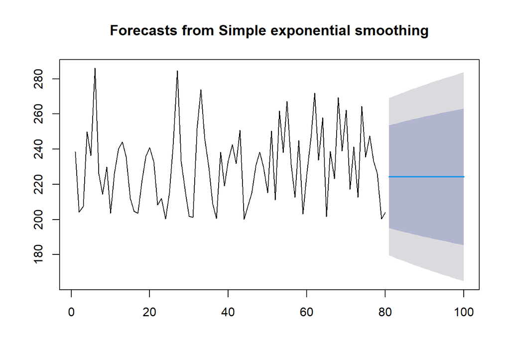

```r
#Cara 1 (fungsi ses)
ses.1 = ses(train.ts, h = 20, alpha = 0.2)
plot(ses.1)
```

```r
ses.1
```

```
##     Point Forecast    Lo 80    Hi 80    Lo 95    Hi 95
##  81       224.3741 195.0974 253.6508 179.5993 269.1490
##  82       224.3741 194.5176 254.2306 178.7126 270.0357
##  83       224.3741 193.9489 254.7994 177.8427 270.9055
##  84       224.3741 193.3906 255.3577 176.9889 271.7594
##  85       224.3741 192.8422 255.9061 176.1501 272.5981
##  86       224.3741 192.3031 256.4452 175.3257 273.4225
##  87       224.3741 191.7730 256.9753 174.5150 274.2333
##  88       224.3741 191.2513 257.4969 173.7172 275.0311
##  89       224.3741 190.7378 258.0105 172.9317 275.8165
##  90       224.3741 190.2319 258.5163 172.1581 276.5901
##  91       224.3741 189.7335 259.0148 171.3958 277.3525
##  92       224.3741 189.2421 259.5062 170.6443 278.1040
##  93       224.3741 188.7575 259.9908 169.9032 278.8451
##  94       224.3741 188.2794 260.4689 169.1720 279.5763
##  95       224.3741 187.8075 260.9407 168.4504 280.2979
##  96       224.3741 187.3417 261.4066 167.7379 281.0103
##  97       224.3741 186.8817 261.8666 167.0343 281.7139
##  98       224.3741 186.4272 262.3211 166.3393 282.4090
##  99       224.3741 185.9781 262.7702 165.6525 283.0958
## 100       224.3741 185.5342 263.2141 164.9736 283.7747
```

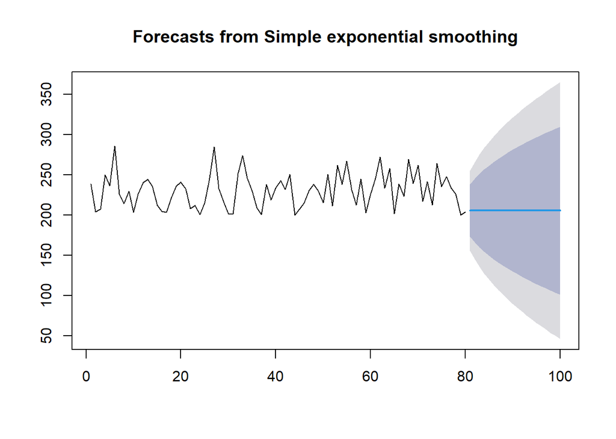

```r
ses.2 = ses(train.ts, h = 20, alpha = 0.7)
plot(ses.2)
```

```r
ses.2
```

```
##     Point Forecast    Lo 80    Hi 80     Lo 95    Hi 95
##  81       205.5669 173.0759 238.0578 155.87624 255.2575
##  82       205.5669 165.9066 245.2271 144.91172 266.2220
##  83       205.5669 159.8480 251.2857 135.64596 275.4878
##  84       205.5669 154.5033 256.6304 127.47192 283.6618
##  85       205.5669 149.6673 261.4664 120.07588 291.0578
##  86       205.5669 145.2176 265.9161 113.27062 297.8631
##  87       205.5669 141.0742 270.0596 106.93379 304.1999
##  88       205.5669 137.1813 273.9524 100.98020 310.1535
##  89       205.5669 133.4984 277.6353  95.34773 315.7860
##  90       205.5669 129.9948 281.1389  89.98942 321.1443
##  91       205.5669 126.6466 284.4871  84.86876 326.2650
##  92       205.5669 123.4348 287.6989  79.95667 331.1770
##  93       205.5669 120.3439 290.7898  75.22958 335.9041
##  94       205.5669 117.3613 293.7725  70.66803 340.4657
##  95       205.5669 114.4762 296.6575  66.25576 344.8780
##  96       205.5669 111.6798 299.4539  61.97902 349.1547
##  97       205.5669 108.9643 302.1694  57.82602 353.3077
##  98       205.5669 106.3231 304.8106  53.78661 357.3471
##  99       205.5669 103.7504 307.3834  49.85196 361.2818
## 100       205.5669 101.2411 309.8927  46.01430 365.1194
```

Pada fungsi `ses()` , terdapat beberapa argumen yang umum digunakan, yaitu

- `y` : nilai data deret waktu
- `alpha` : parameter pemulusan utama (0–1), mengatur bobot data terbaru vs data lama.
- `beta` : parameter pemulusan tren.
- `gamma` : parameter pemulusan musiman.
- `h` : jumlah periode ke depan yang ingin diramalkan (forecast horizon).

Untuk mendapatkan gambar hasil pemulusan pada data latih dengan fungsi `ses()` , perlu digunakan fungsi `autoplot()` dan `autolayer()` dari *library packages* `ggplot2` .

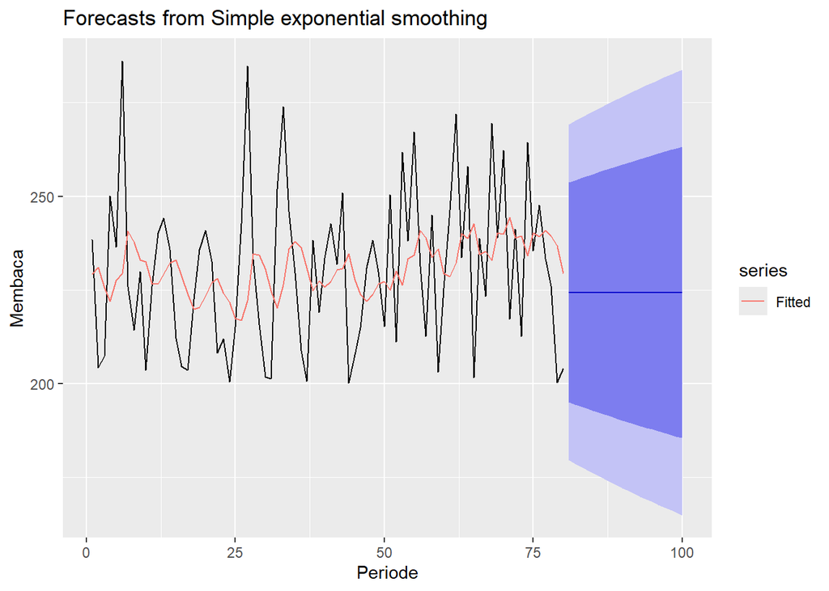

```r
autoplot(ses.1) +
  autolayer(fitted(ses.1), series="Fitted") +
  ylab("Membaca") + xlab("Periode")
```

Selanjutnya akan digunakan fungsi `HoltWinters()` dengan nilai inisialisasi parameter dan panjang periode peramalan yang sama dengan fungsi `ses()` .

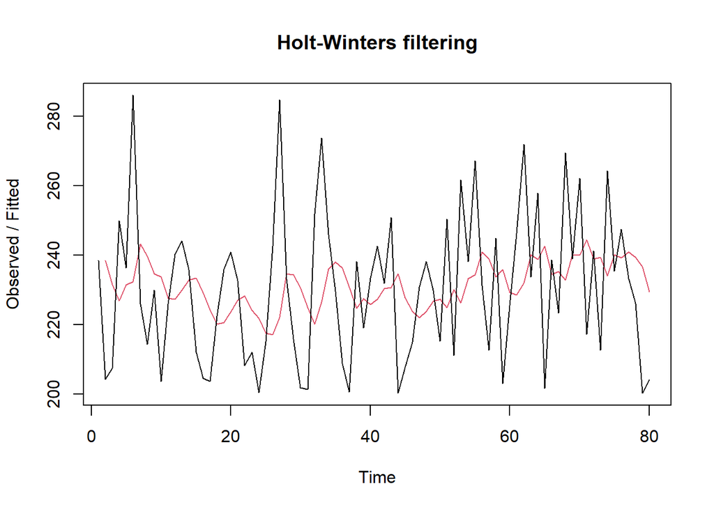

```r
#Cara 2 (fungsi Holtwinter)
ses1 = HoltWinters(train.ts, gamma = FALSE, beta = FALSE, alpha = 0.2)
plot(ses1)
```

```r
#ramalan
ramalan1 = forecast(ses1, h=20)
ramalan1
```

```
##     Point Forecast    Lo 80    Hi 80    Lo 95    Hi 95
##  81       224.3741 195.0335 253.7148 179.5015 269.2468
##  82       224.3741 194.4524 254.2958 178.6128 270.1354
##  83       224.3741 193.8824 254.8658 177.7411 271.0072
##  84       224.3741 193.3229 255.4254 176.8854 271.8629
##  85       224.3741 192.7733 255.9750 176.0448 272.7035
##  86       224.3741 192.2331 256.5152 175.2186 273.5297
##  87       224.3741 191.7018 257.0465 174.4061 274.3422
##  88       224.3741 191.1790 257.5693 173.6065 275.1417
##  89       224.3741 190.6643 258.0840 172.8194 275.9289
##  90       224.3741 190.1573 258.5909 172.0441 276.7042
##  91       224.3741 189.6578 259.0905 171.2801 277.4682
##  92       224.3741 189.1654 259.5829 170.5270 278.2213
##  93       224.3741 188.6797 260.0686 169.7842 278.9641
##  94       224.3741 188.2006 260.5477 169.0514 279.6969
##  95       224.3741 187.7277 261.0206 168.3282 280.4201
##  96       224.3741 187.2608 261.4874 167.6142 281.1340
##  97       224.3741 186.7998 261.9485 166.9091 281.8392
##  98       224.3741 186.3443 262.4040 166.2125 282.5357
##  99       224.3741 185.8942 262.8540 165.5242 283.2241
## 100       224.3741 185.4494 263.2989 164.8438 283.9044
```

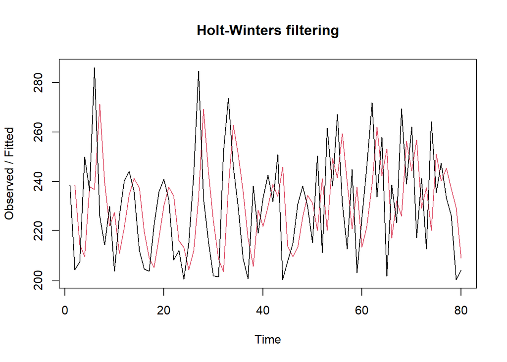

```r
ses2 = HoltWinters(train.ts, gamma = FALSE, beta = FALSE, alpha = 0.7)
plot(ses2)
```

```r
#ramalan
ramalan2 = forecast(ses2, h=20)
ramalan2
```

```
##     Point Forecast    Lo 80    Hi 80     Lo 95    Hi 95
##  81       205.5669 173.0570 238.0767 155.84731 255.2864
##  82       205.5669 165.8835 245.2502 144.87642 266.2573
##  83       205.5669 159.8214 251.3123 135.60526 275.5285
##  84       205.5669 154.4736 256.6601 127.42646 283.7073
##  85       205.5669 149.6348 261.4989 120.02612 291.1076
##  86       205.5669 145.1825 265.9512 113.21690 297.9168
##  87       205.5669 141.0366 270.0971 106.87638 304.2573
##  88       205.5669 137.1415 273.9922 100.91932 310.2144
##  89       205.5669 133.4565 277.6772  95.28357 315.8501
##  90       205.5669 129.9508 281.1829  89.92215 321.2116
##  91       205.5669 126.6007 284.5330  84.79850 326.3352
##  92       205.5669 123.3870 287.7467  79.88356 331.2502
##  93       205.5669 120.2943 290.8394  75.15372 335.9800
##  94       205.5669 117.3099 293.8238  70.58951 340.5442
##  95       205.5669 114.4232 296.7105  66.17468 344.9590
##  96       205.5669 111.6252 299.5085  61.89544 349.2383
##  97       205.5669 108.9081 302.2256  57.74002 353.3937
##  98       205.5669 106.2653 304.8684  53.69827 357.4354
##  99       205.5669 103.6911 307.4426  49.76132 361.3724
## 100       205.5669 101.1803 309.9534  45.92143 365.2123
```

Fungsi `HoltWinters` memiliki argumen yang sama dengan fungsi `ses()` . Argumen-argumen kedua fungsi dapat dilihat lebih lanjut dengan `?ses()` atau `?HoltWinters` .

Nilai parameter $\alpha$ dari kedua fungsi dapat dioptimalkan menyesuaikan dari *error*-nya paling minimumnya. Caranya adalah dengan membuat parameter $\alpha =$ `NULL` .

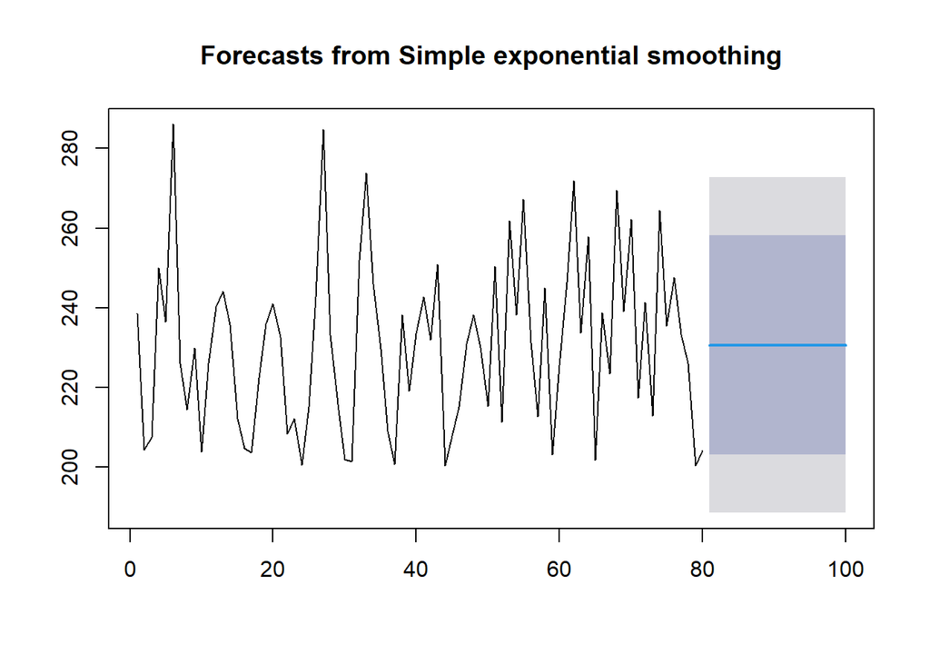

```r
#SES
ses.opt <- ses(train.ts, h = 20, alpha = NULL)
plot(ses.opt)
```

```r
ses.opt
```

```
##     Point Forecast    Lo 80    Hi 80    Lo 95    Hi 95
##  81       230.5971 203.0219 258.1722 188.4245 272.7696
##  82       230.5971 203.0219 258.1722 188.4245 272.7696
##  83       230.5971 203.0219 258.1722 188.4245 272.7696
##  84       230.5971 203.0219 258.1722 188.4245 272.7696
##  85       230.5971 203.0219 258.1722 188.4245 272.7696
##  86       230.5971 203.0219 258.1722 188.4245 272.7696
##  87       230.5971 203.0219 258.1722 188.4245 272.7696
##  88       230.5971 203.0219 258.1722 188.4245 272.7696
##  89       230.5971 203.0219 258.1722 188.4245 272.7696
##  90       230.5971 203.0219 258.1722 188.4245 272.7696
##  91       230.5971 203.0219 258.1722 188.4245 272.7696
##  92       230.5971 203.0219 258.1722 188.4245 272.7696
##  93       230.5971 203.0219 258.1722 188.4245 272.7696
##  94       230.5971 203.0219 258.1722 188.4245 272.7696
##  95       230.5971 203.0219 258.1722 188.4245 272.7696
##  96       230.5971 203.0219 258.1722 188.4245 272.7696
##  97       230.5971 203.0219 258.1722 188.4245 272.7696
##  98       230.5971 203.0219 258.1722 188.4245 272.7696
##  99       230.5971 203.0219 258.1722 188.4245 272.7696
## 100       230.5971 203.0219 258.1722 188.4245 272.7696
```

```r
#Lamda Optimum Holt Winter
HWopt<- HoltWinters(train.ts, gamma = FALSE, beta = FALSE,alpha = NULL)
HWopt
```

```
## Holt-Winters exponential smoothing without trend and without seasonal component.
##
## Call:
## HoltWinters(x = train.ts, alpha = NULL, beta = FALSE, gamma = FALSE)
##
## Smoothing parameters:
##  alpha: 0.03919422
##  beta : FALSE
##  gamma: FALSE
##
## Coefficients:
##       [,1]
## a 232.4459
```

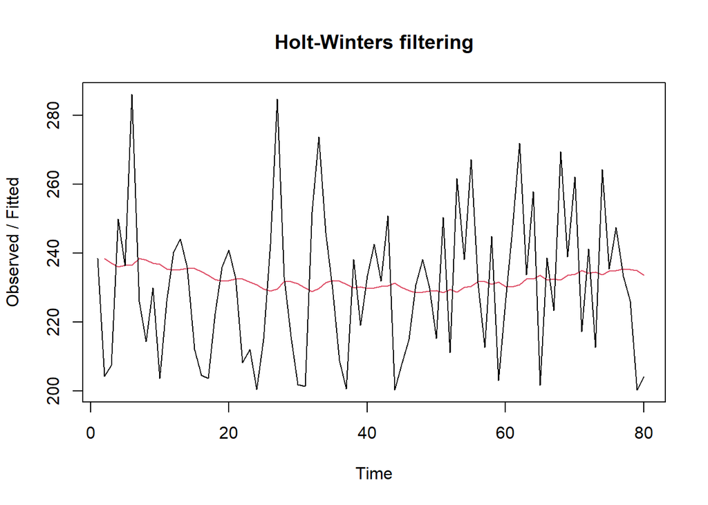

```r
plot(HWopt)
```

```r
#ramalan
ramalanopt<- forecast(HWopt, h=20)
ramalanopt
```

```
##     Point Forecast    Lo 80    Hi 80    Lo 95    Hi 95
##  81       232.4459 204.1865 260.7052 189.2269 275.6648
##  82       232.4459 204.1648 260.7269 189.1937 275.6980
##  83       232.4459 204.1431 260.7486 189.1606 275.7312
##  84       232.4459 204.1215 260.7703 189.1274 275.7643
##  85       232.4459 204.0998 260.7919 189.0943 275.7974
##  86       232.4459 204.0782 260.8136 189.0612 275.8305
##  87       232.4459 204.0566 260.8352 189.0282 275.8636
##  88       232.4459 204.0350 260.8568 188.9952 275.8966
##  89       232.4459 204.0134 260.8784 188.9621 275.9296
##  90       232.4459 203.9918 260.8999 188.9292 275.9626
##  91       232.4459 203.9703 260.9215 188.8962 275.9955
##  92       232.4459 203.9487 260.9430 188.8633 276.0285
##  93       232.4459 203.9272 260.9645 188.8304 276.0614
##  94       232.4459 203.9057 260.9860 188.7975 276.0943
##  95       232.4459 203.8842 261.0075 188.7646 276.1271
##  96       232.4459 203.8628 261.0290 188.7318 276.1599
##  97       232.4459 203.8413 261.0504 188.6990 276.1928
##  98       232.4459 203.8199 261.0719 188.6662 276.2255
##  99       232.4459 203.7985 261.0933 188.6335 276.2583
## 100       232.4459 203.7771 261.1147 188.6007 276.2910
```

Setelah dilakukan peramalan, akan dilakukan perhitungan keakuratan hasil peramalan. Perhitungan akurasi ini dilakukan baik pada data latih dan data uji.

#### Akurasi Data Latih

Perhitungan akurasi data dapat dilakukan dengan cara langsung maupun manual. Secara langsung, nilai akurasi dapat diambil dari objek yang tersimpan pada hasil SES, yaitu *sum of squared errors* (SSE). Nilai akurasi lain dapat dihitung pula dari nilai SSE tersebut.

```r
#Keakuratan Metode
#Pada data training

# SES dengan alpha = 0.2
SSE1 = ses1$SSE
MSE1 = ses1$SSE/length(train.ts)
RMSE1 = sqrt(MSE1)

akurasi1 = matrix(c(SSE1,MSE1,RMSE1))
row.names(akurasi1) = c("SSE", "MSE", "RMSE")
colnames(akurasi1) = c("Akurasi lamda=0.2")
akurasi1
```

```
##      Akurasi lamda=0.2
## SSE        40947.85671
## MSE          511.84821
## RMSE          22.62406
```

```r
# SES dengan alpha = 0.7
SSE2 = ses2$SSE
MSE2 = ses2$SSE/length(train.ts)
RMSE2 = sqrt(MSE2)

akurasi2 = matrix(c(SSE2,MSE2,RMSE2))
row.names(akurasi2) = c("SSE", "MSE", "RMSE")
colnames(akurasi2) = c("Akurasi lamda=0.7")
akurasi2
```

```
##      Akurasi lamda=0.7
## SSE        50222.10517
## MSE          627.77631
## RMSE          25.05546
```

#### Akurasi Data Uji

Akurasi data uji dapat dihitung dengan cara yang hampir sama dengan perhitungan akurasi data latih.

```r
# jumlah observasi uji
n_test <- nrow(testing)

# error (ramalan - aktual), samakan panjang dan tipe numeric
e1   <- as.numeric(ramalan1$mean)[1:n_test] - as.numeric(testing$Total_Sales)
e2   <- as.numeric(ramalan2$mean)[1:n_test] - as.numeric(testing$Total_Sales)
eopt <- as.numeric(ramalanopt$mean)[1:n_test] - as.numeric(testing$Total_Sales)

# SSE / MSE / RMSE untuk masing-masing model (abaikan NA)
SSEtesting1  <- sum(e1^2,  na.rm = TRUE)
MSEtesting1  <- mean(e1^2, na.rm = TRUE)
RMSEtesting1 <- sqrt(MSEtesting1)

SSEtesting2  <- sum(e2^2,  na.rm = TRUE)
MSEtesting2  <- mean(e2^2, na.rm = TRUE)
RMSEtesting2 <- sqrt(MSEtesting2)

SSEtestingopt  <- sum(eopt^2,  na.rm = TRUE)
MSEtestingopt  <- mean(eopt^2, na.rm = TRUE)
RMSEtestingopt <- sqrt(MSEtestingopt)

# Tabel ringkas
akurasitesting_SSE <- matrix(c(SSEtesting1, SSEtesting2, SSEtestingopt),
                             nrow = 3,
                             dimnames = list(c("SSE1","SSE2","SSEopt"), "Nilai"))
akurasitesting_MSE <- matrix(c(MSEtesting1, MSEtesting2, MSEtestingopt),
                             nrow = 3,
                             dimnames = list(c("MSE1","MSE2","MSEopt"), "Nilai"))
akurasitesting_RMSE <- matrix(c(RMSEtesting1, RMSEtesting2, RMSEtestingopt),
                              nrow = 3,
                              dimnames = list(c("RMSE1","RMSE2","RMSEopt"), "Nilai"))

akurasitesting_SSE
```

```
##            Nilai
## SSE1    8672.019
## SSE2   22163.232
## SSEopt  7221.043
```

```r
akurasitesting_MSE
```

```
##            Nilai
## MSE1    433.6009
## MSE2   1108.1616
## MSEopt  361.0522
```

```r
akurasitesting_RMSE
```

```
##            Nilai
## RMSE1   20.82309
## RMSE2   33.28906
## RMSEopt 19.00137
```

Selain dengan cara di atas, perhitungan nilai akurasi dapat menggunakan fungsi `accuracy()` dari *package* `forecast` . Penggunaannya yaitu dengan menuliskan `accuracy(hasil ramalan, kondisi aktual)` . Contohnya adalah sebagai berikut.

```r
# Potong data testing agar panjangnya sama dengan ramalan
actual1 <- testing$Total_Sales[1:length(ramalan1$mean)]
actual2 <- testing$Total_Sales[1:length(ramalan2$mean)]
actualopt <- testing$Total_Sales[1:length(ramalanopt$mean)]

# Hitung akurasi dengan panjang yang cocok
accuracy(ramalan1, actual1)
```

```
##                      ME     RMSE      MAE       MPE     MAPE      MASE
## Training set -0.8934093 22.76680 18.73105 -1.244116 8.151149 0.8021429
## Test set      8.5298676 20.82309 16.72076  3.022518 6.987823 0.7160537
##                    ACF1
## Training set 0.09485997
## Test set             NA
```

```r
accuracy(ramalan2, actual2)
```

```
##                      ME     RMSE      MAE       MPE      MAPE      MASE
## Training set -0.5953552 25.21354 21.55706 -1.020979  9.304053 0.9231643
## Test set     27.3371420 33.28906 28.14883 11.151272 11.562356 1.2054519
##                    ACF1
## Training set -0.1920365
## Test set             NA
```

```r
accuracy(ramalanopt, actualopt)
```

```
##                      ME     RMSE      MAE        MPE     MAPE      MASE
## Training set -1.9520209 21.99767 17.83761 -1.7066992 7.807157 0.7638819
## Test set      0.4581264 19.00137 15.04400 -0.4661955 6.484786 0.6442477
##                  ACF1
## Training set 0.162544
## Test set           NA
```

## *Double Exponential Smoothing* (DES)

Metode pemulusan *Double Exponential Smoothing* (DES) digunakan untuk data yang memiliki pola tren. Metode DES adalah metode semacam SES, hanya saja dilakukan dua kali, yaitu pertama untuk tahapan ‘level’ dan kedua untuk tahapan ‘tren’. Pemulusan menggunakan metode ini akan menghasilkan peramalan tidak konstan untuk periode berikutnya.

Pemulusan dengan metode DES kali ini akan menggunakan fungsi `HoltWinters()` . Jika sebelumnya nilai argumen `beta` dibuat `FALSE` , kali ini argumen tersebut akan diinisialisasi bersamaan dengan nilai `alpha` .

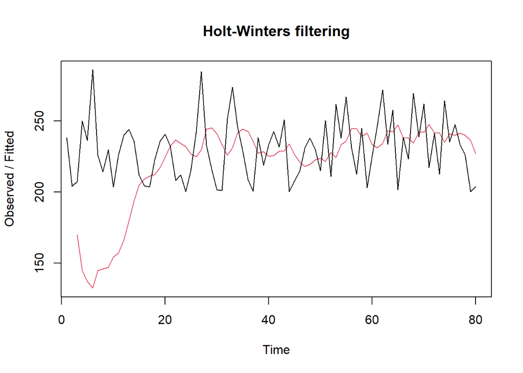

```r
#Lamda=0.2 dan gamma=0.2
des.1<- HoltWinters(train.ts, gamma = FALSE, beta = 0.2, alpha = 0.2)
plot(des.1)
```

```r
#ramalan
ramalandes1<- forecast(des.1, h=20)
ramalandes1
```

```
##     Point Forecast     Lo 80    Hi 80       Lo 95    Hi 95
##  81       219.6232 171.16093 268.0854 145.5065782 293.7397
##  82       216.6273 166.78890 266.4657 140.4060388 292.8486
##  83       213.6314 161.97879 265.2841 134.6355308 292.6273
##  84       210.6356 156.70514 264.5660 128.1560967 293.1150
##  85       207.6397 150.95754 264.3219 120.9518105 294.3276
##  86       204.6438 144.73856 264.5491 113.0266257 296.2611
##  87       201.6480 138.06080 265.2351 104.3997840 298.8962
##  88       198.6521 130.94359 266.3606  95.1008685 302.2033
##  89       195.6562 123.41013 267.9024  85.1653436 306.1471
##  90       192.6604 115.48513 269.8356  74.6310270 310.6897
##  91       189.6645 107.19325 272.1358  63.5355942 315.7934
##  92       186.6686  98.55797 274.7793  51.9149960 321.4223
##  93       183.6728  89.60112 277.7445  39.8025851 327.5430
##  94       180.6769  80.34255 281.0113  27.2287379 334.1251
##  95       177.6811  70.80014 284.5620  14.2207962 341.1413
##  96       174.6852  60.98987 288.3805   0.8031962 348.5672
##  97       171.6893  50.92596 292.4527 -13.0023037 356.3810
##  98       168.6935  40.62107 296.7658 -27.1763552 364.5633
##  99       165.6976  30.08646 301.3087 -41.7017459 373.0969
## 100       162.7017  19.33214 306.0713 -56.5631382 381.9666
```

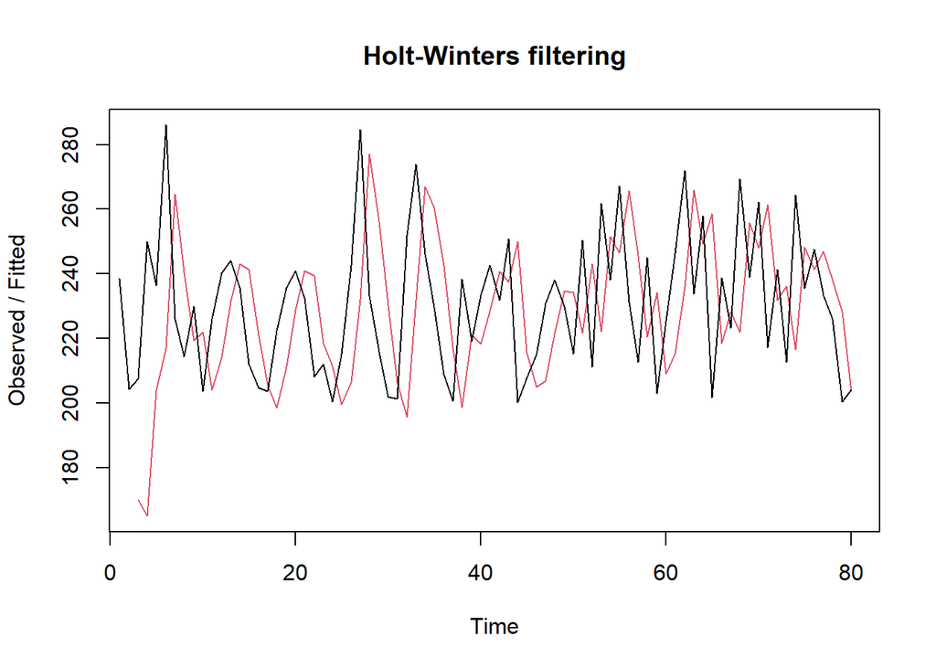

```r
#Lamda=0.6 dan gamma=0.3
des.2<- HoltWinters(train.ts, gamma = FALSE, beta = 0.3, alpha = 0.6)
plot(des.2)
```

```r
#ramalan
ramalandes2<- forecast(des.2, h=20)
ramalandes2
```

```
##     Point Forecast       Lo 80    Hi 80      Lo 95    Hi 95
##  81      196.21640  157.988976 234.4438  137.75260 254.6802
##  82      188.50989  140.028839 236.9909  114.36452 262.6553
##  83      180.80339  119.998948 241.6078   87.81102 273.7958
##  84      173.09688   98.288246 247.9055   58.68695 287.5068
##  85      165.39037   75.154221 255.6265   27.38609 303.3947
##  86      157.68387   50.770028 264.5977   -5.82674 321.1945
##  87      149.97736   25.257502 274.6972  -40.76520 340.7199
##  88      142.27086   -1.293349 285.8351  -77.29165 361.8334
##  89      134.56435  -28.813055 297.9418 -115.29983 384.4285
##  90      126.85784  -57.245997 310.9617 -154.70468 408.4204
##  91      119.15134  -86.546302 324.8490 -195.43605 433.7387
##  92      111.44483 -116.675213 339.5649 -237.43467 460.3243
##  93      103.73833 -147.599350 355.0760 -280.64948 488.1261
##  94       96.03182 -179.289502 371.3531 -325.03581 517.0994
##  95       88.32531 -211.719780 388.3704 -370.55406 547.2047
##  96       80.61881 -244.866992 406.1046 -417.16877 578.4064
##  97       72.91230 -278.710177 424.5348 -464.84787 610.6725
##  98       65.20579 -313.230247 443.6418 -513.56219 643.9738
##  99       57.49929 -348.409706 463.4083 -563.28495 678.2835
## 100       49.79278 -384.232429 483.8180 -613.99150 713.5771
```

Selanjutnya jika ingin membandingkan plot data latih dan data uji adalah sebagai berikut.

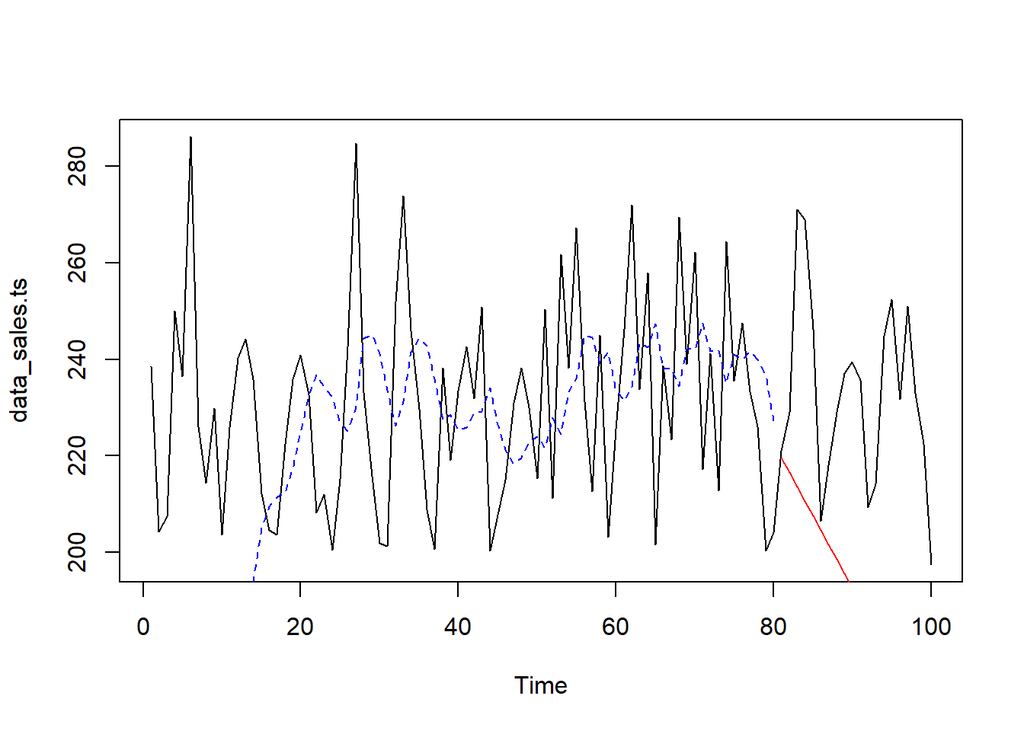

```r
plot(data_sales.ts)
lines(des.1$fitted[,1], lty=2, col="blue")
lines(ramalandes1$mean, col="red")
```

Untuk mendapatkan nilai parameter optimum dari DES, argumen `alpha` dan `beta` dapat dibuat `NULL` seperti berikut.

```r
#Lamda dan gamma optimum
des.opt<- HoltWinters(train.ts, gamma = FALSE)
des.opt
```

```
## Holt-Winters exponential smoothing with trend and without seasonal component.
##
## Call:
## HoltWinters(x = train.ts, gamma = FALSE)
##
## Smoothing parameters:
##  alpha: 0.7056246
##  beta : 0.1546692
##  gamma: FALSE
##
## Coefficients:
##         [,1]
## a 204.000734
## b  -4.539343
```

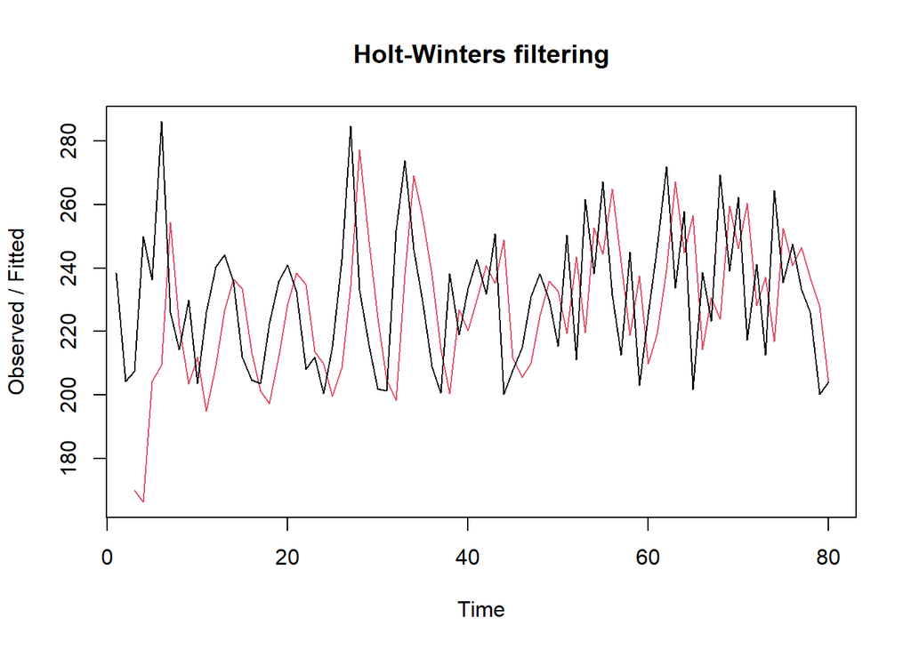

```r
plot(des.opt)
```

```r
#ramalan
ramalandesopt<- forecast(des.opt, h=20)
ramalandesopt
```

```
##     Point Forecast       Lo 80    Hi 80       Lo 95    Hi 95
##  81       199.4614  162.312247 236.6105  142.646677 256.2761
##  82       194.9220  147.003415 242.8407  121.636823 268.2073
##  83       190.3827  131.440319 249.3251  100.238105 280.5273
##  84       185.8434  115.508707 256.1780   78.275790 293.4109
##  85       181.3040   99.161776 263.4463   55.678299 306.9297
##  86       176.7647   82.381233 271.1481   32.417656 321.1117
##  87       172.2253   65.162273 279.2884    8.486513 335.9642
##  88       167.6860   47.506884 287.8651  -16.112092 351.4841
##  89       163.1466   29.420557 296.8727  -41.369758 367.6631
##  90       158.6073   10.910576 306.3040  -67.275348 384.4900
##  91       154.0680   -8.014928 316.1508  -93.816427 401.9523
##  92       149.5286  -27.347503 326.4047 -120.980065 420.0373
##  93       144.9893  -47.078674 337.0572 -148.753304 438.7319
##  94       140.4499  -67.200119 348.1000 -177.123416 458.0233
##  95       135.9106  -87.703764 359.5249 -206.078052 477.8992
##  96       131.3712 -108.581830 371.3243 -235.605315 498.3478
##  97       126.8319 -129.826857 383.4907 -265.693797 519.3576
##  98       122.2926 -151.431711 396.0168 -296.332587 540.9177
##  99       117.7532 -173.389579 408.8960 -327.511265 563.0177
## 100       113.2139 -195.693957 422.1217 -359.219885 585.6476
```

Selanjutnya akan dilakukan perhitungan akurasi pada data latih maupun data uji dengan ukuran akurasi SSE, MSE dan MAPE.

#### Akurasi Data Latih

```r
#Akurasi Data Training
ssedes.train1<-des.1$SSE
msedes.train1<-ssedes.train1/length(train.ts)
sisaandes1<-ramalandes1$residuals
head(sisaandes1)
```

```
## Time Series:
## Start = 1
## End = 6
## Frequency = 1
## [1]        NA        NA  37.45000 105.22200  99.08072 153.53447
```

```r
mapedes.train1 <- sum(abs(sisaandes1[3:length(train.ts)]/train.ts[3:length(train.ts)])
                      *100)/length(train.ts)

akurasides.1 <- matrix(c(ssedes.train1,msedes.train1,mapedes.train1))
row.names(akurasides.1)<- c("SSE", "MSE", "MAPE")
colnames(akurasides.1) <- c("Akurasi lamda=0.2 dan gamma=0.2")
akurasides.1
```

```
##      Akurasi lamda=0.2 dan gamma=0.2
## SSE                     117926.71682
## MSE                       1474.08396
## MAPE                        11.84989
```

```r
ssedes.train2<-des.2$SSE
msedes.train2<-ssedes.train2/length(train.ts)
sisaandes2<-ramalandes2$residuals
head(sisaandes2)
```

```
## Time Series:
## Start = 1
## End = 6
## Frequency = 1
## [1]       NA       NA 37.45000 84.99900 32.56878 69.06431
```

```r
mapedes.train2 <- sum(abs(sisaandes2[3:length(train.ts)]/train.ts[3:length(train.ts)])
                      *100)/length(train.ts)

akurasides.2 <- matrix(c(ssedes.train2,msedes.train2,mapedes.train2))
row.names(akurasides.2)<- c("SSE", "MSE", "MAPE")
colnames(akurasides.2) <- c("Akurasi lamda=0.6 dan gamma=0.3")
akurasides.2
```

```
##      Akurasi lamda=0.6 dan gamma=0.3
## SSE                       68790.6779
## MSE                         859.8835
## MAPE                         10.4216
```

#### Akurasi Data Uji

```r
#Akurasi Data Testing
selisihdes1<-ramalandes1$mean-testing$Total_Sales
selisihdes1
```

```
## Time Series:
## Start = 81
## End = 100
## Frequency = 1
##  [1]  -1.346837 -12.402702 -57.308567 -58.364431 -38.600296  -1.786161
##  [7] -16.362026 -30.417891 -41.463756 -46.759621 -45.935485 -22.571350
## [13] -30.557215 -64.203080 -74.638945 -57.104810 -79.350675 -64.226539
## [19] -56.682404 -34.748269
```

```r
SSEtestingdes1<-sum(selisihdes1^2)
MSEtestingdes1<-SSEtestingdes1/length(testing$Total_Sales)
MAPEtestingdes1<-sum(abs(selisihdes1/testing$Total_Sales)*100)/length(testing$Total_Sales)

selisihdes2<-ramalandes2$mean-testing$Total_Sales
selisihdes2
```

```
## Time Series:
## Start = 81
## End = 100
## Frequency = 1
##  [1]  -24.75360  -40.52011  -90.13661  -95.90312  -80.84963  -48.74613
##  [7]  -68.03264  -86.79914 -102.55565 -112.56216 -116.44866  -97.79517
## [13] -110.49167 -148.84818 -163.99469 -151.17119 -178.12770 -167.71421
## [19] -164.88071 -147.65722
```

```r
SSEtestingdes2<-sum(selisihdes2^2)
MSEtestingdes2<-SSEtestingdes2/length(testing$Total_Sales)
MAPEtestingdes2<-sum(abs(selisihdes2/testing$Total_Sales)*100)/length(testing$Total_Sales)

selisihdesopt<-ramalandesopt$mean-testing$Total_Sales
selisihdesopt
```

```
## Time Series:
## Start = 81
## End = 100
## Frequency = 1
##  [1]  -21.50861  -34.10795  -80.55729  -83.15664  -64.93598  -29.66532
##  [7]  -45.78467  -61.38401  -73.97335  -80.81270  -81.53204  -59.71138
## [13]  -69.24073 -104.43007 -116.40941 -100.41876 -124.20810 -110.62744
## [19] -104.62678  -84.23613
```

```r
SSEtestingdesopt<-sum(selisihdesopt^2)
MSEtestingdesopt<-SSEtestingdesopt/length(testing$Total_Sales)
MAPEtestingdesopt<-sum(abs(selisihdesopt/testing$Total_Sales)*100)/length(testing$Total_Sales)

akurasitestingdes <-
  matrix(c(SSEtestingdes1,MSEtestingdes1,MAPEtestingdes1,SSEtestingdes2,MSEtestingdes2,
           MAPEtestingdes2,SSEtestingdesopt,MSEtestingdesopt,MAPEtestingdesopt),
         nrow=3,ncol=3)
row.names(akurasitestingdes)<- c("SSE", "MSE", "MAPE")
colnames(akurasitestingdes) <- c("des ske1","des ske2","des opt")
akurasitestingdes
```

```
##         des ske1     des ske2      des opt
## SSE  44787.32202 279921.11413 133250.66055
## MSE   2239.36610  13996.05571   6662.53303
## MAPE    17.52351     47.21252     32.65071
```

#### Perbandingan SES dan DES

```r
MSEfull <-
  matrix(c(MSEtesting1,MSEtesting2,MSEtestingopt,MSEtestingdes1,MSEtestingdes2,
           MSEtestingdesopt),nrow=3,ncol=2)
row.names(MSEfull)<- c("ske 1", "ske 2", "ske opt")
colnames(MSEfull) <- c("ses","des")
MSEfull
```

```
##               ses       des
## ske 1    433.6009  2239.366
## ske 2   1108.1616 13996.056
## ske opt  361.0522  6662.533
```

## Pemulusan Data Musiman

Pertama impor kembali data baru untuk latihan data musiman.

```r
#Import data
library(rio)
data3 <- import("https://raw.githubusercontent.com/rizkynurhambali/praktikum-sta1341/main/Pertemuan%201/Electric_Production.csv")
data3.ts <- ts(data3$Yt)
```

Selanjutnya melakukan pembagian data dan mengubahnya menjadi data deret waktu.

```r
#membagi data menjadi training dan testing
training<-data3[1:192,2]
testing<-data3[193:241,2]
training.ts<-ts(training, frequency = 13)
testing.ts<-ts(testing, frequency = 13)
```

Kemudian akan dilakukan eskplorasi dengan plot data deret waktu sebagai berikut.

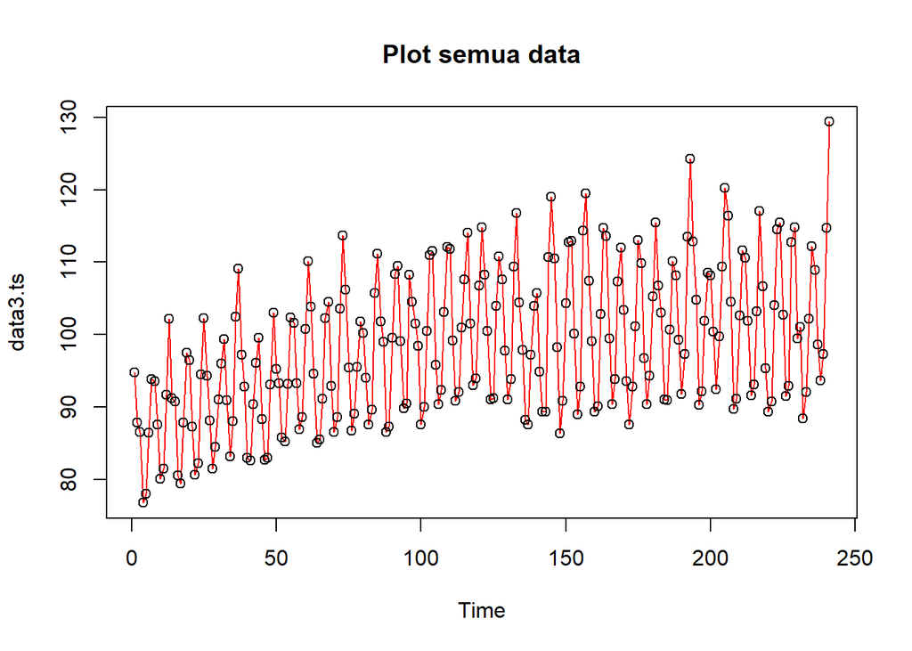

```r
#Membuat plot time series
plot(data3.ts, col="red",main="Plot semua data")
points(data3.ts)
```

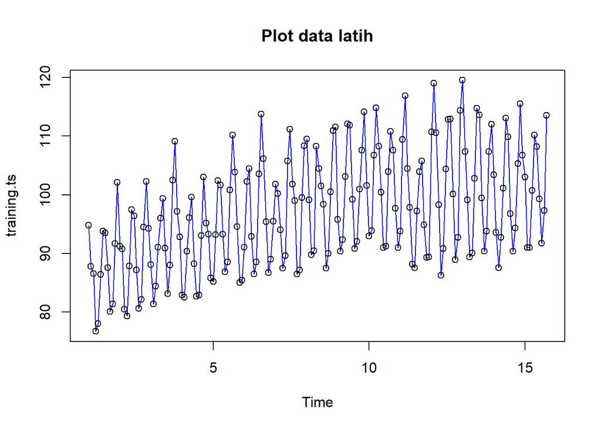

```r
plot(training.ts, col="blue",main="Plot data latih")
points(training.ts)
```

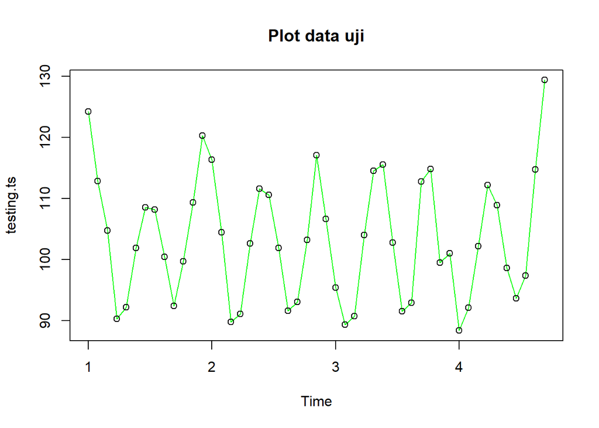

```r
plot(testing.ts, col="green",main="Plot data uji")
points(testing.ts)
```

Metode Holt-Winter untuk peramalan data musiman menggunakan tiga persamaan pemulusan yang terdiri atas persamaan untuk level $(L_t)$, trend $(B_t)$, dan komponen seasonal / musiman $(S_t)$ dengan parameter pemulusan berupa $\alpha$, $\beta$, dan $\gamma$. Metode Holt-Winter musiman terbagi menjadi dua, yaitu metode aditif dan metode multiplikatif. Perbedaan persamaan dan contoh datanya adalah sebagai berikut.

[figure not shown]

Pemulusan data musiman dengan metode Winter dilakukan menggunakan fungsi `HoltWinters()` dengan memasukkan argumen tambahan, yaitu `gamma()` dan `seasonal()` . Arguman `seasonal()` diinisialisasi menyesuaikan jenis musiman, aditif atau multiplikatif.

### Winter Aditif

Perhitungan dengan model aditif dilakukan jika plot data asli menunjukkan fluktuasi musiman yang relatif stabil (konstan).

#### Pemulusan

```r
#Pemulusan dengan winter aditif
winter1 <- HoltWinters(training.ts,alpha=0.2,beta=0.1,gamma=0.1,seasonal = "additive")
winter1$fitted
```

```
## Time Series:
## Start = c(2, 1)
## End = c(15, 10)
## Frequency = 13
##                xhat     level        trend        season
##  2.000000  88.54720  87.09424  0.182710904  1.2702538462
##  2.076923  89.35006  87.80409  0.235424883  1.3105461538
##  2.153846  80.20116  88.31712  0.263185721 -8.3791461538
##  2.230769  79.24275  88.64359  0.269514524 -9.6703615385
##  2.307692  86.99289  88.94230  0.272433583 -2.2218384615
##  2.384615  96.28834  89.38477  0.289437697  6.6141307692
##  2.461538  96.00536  89.91460  0.313476850  5.7772846154
##  2.538462  96.01483  90.31015  0.321683558  5.3830000000
##  2.615385  88.18864  88.87382  0.145882946 -0.8310692308
##  2.692308  79.68943  87.51016 -0.005071818 -7.8156615385
##  2.769231  81.37692  88.00770  0.045189654 -6.6759769231
##  2.846154  93.80604  90.67977  0.307877345  2.8183923077
##  2.923077 105.56926  92.67246  0.476358567 12.4204461538
##  3.000000  92.62681  90.89474  0.250951296  1.4811097582
##  3.076923  91.82073  90.23887  0.160269181  1.4215895083
##  3.153846  79.92237  88.32350 -0.047295489 -8.3538309434
##  3.230769  79.56744  89.18277  0.043361094 -9.6586853012
##  3.307692  89.63976  91.52076  0.272824225 -2.1538220045
##  3.384615 100.17500  93.06477  0.399942979  6.7102873806
##  3.461538  99.49776  93.30379  0.383850936  5.8101114488
##  3.538462  96.86370  91.97165  0.212251801  4.6797975513
##  3.615385  87.94223  89.43933 -0.062206265 -1.4348882870
##  3.692308  81.72203  89.39687 -0.060230876 -7.6146156534
##  3.769231  88.21262  93.48340  0.354444600 -5.6252261566
##  3.846154 102.28161  98.01694  0.772354299  3.4923171948
##  3.923077 109.95628  97.76731  0.670156106 11.5188170705
##  4.000000  96.45785  95.01187  0.327596431  1.1183812995
##  4.076923  93.27897  92.63090  0.056739478  0.5913308268
##  4.153846  82.39203  90.54114 -0.157909864 -7.9912046133
##  4.230769  83.24525  91.98393  0.002159568 -8.7408327760
##  4.307692  93.16522  94.55184  0.258734485 -1.6453469861
##  4.384615 103.12062  96.08821  0.386498014  6.6459192062
##  4.461538  98.72020  93.50678  0.089705553  5.1237149089
##  4.538462  93.74063  90.38964 -0.230978441  3.5819652871
##  4.615385  86.12278  87.99692 -0.447153075 -1.4269867301
```

[output cut: 129 more lines]

```
## 14.615385 101.50983 100.87589 -0.039617605  0.6735538408
## 14.692308  95.34420  98.61041 -0.262204177 -3.0040083612
## 14.769231  93.79057  98.14771 -0.282254107 -4.0748858368
## 14.846154 100.63922 100.16178 -0.052621419  0.5300636299
## 14.923077 108.52678 103.08151  0.244614170  5.2006486056
## 15.000000 105.10792 102.96757  0.208758658  1.9315910555
## 15.076923 104.19741 102.75371  0.166496227  1.2772062730
## 15.153846  97.53718 100.28256 -0.097267947 -2.6481099535
## 15.230769  93.60600  98.87054 -0.228743603 -5.0357906646
## 15.307692  97.39566 100.05973 -0.086949641 -2.5771193498
## 15.384615 104.65059 102.52325  0.168097095  1.9592438048
## 15.461538 106.32013 103.39635  0.238597278  2.6851847820
## 15.538462 104.51802 102.22710  0.097812660  2.1931081356
## 15.615385  99.40513  99.77873 -0.156805755 -0.2167924469
## 15.692308  95.91455  99.19796 -0.199202360 -3.0842080810
```

```r
xhat1 <- winter1$fitted[,2]

winter1.opt<- HoltWinters(training.ts, alpha= NULL,  beta = NULL, gamma = NULL, seasonal = "additive")
winter1.opt
```

```
## Holt-Winters exponential smoothing with trend and additive seasonal component.
##
## Call:
## HoltWinters(x = training.ts, alpha = NULL, beta = NULL, gamma = NULL,     seasonal = "additive")
##
## Smoothing parameters:
##  alpha: 0.4047538
##  beta : 0
##  gamma: 1
##
## Coefficients:
##            [,1]
## a   109.2446603
## b     0.1827109
## s1   -0.8266228
## s2    5.6964456
## s3    0.3679335
## s4   -1.1981680
## s5   -9.2800809
## s6   -8.1509015
## s7   -0.8688158
## s8    4.3878031
## s9    3.5559231
## s10  -1.7827396
## s11  -7.2290284
## s12  -4.4226157
## s13   4.2285397
```

```r
winter1.opt$fitted
```

```
## Time Series:
## Start = c(2, 1)
## End = c(15, 10)
## Frequency = 13
##                xhat     level     trend       season
##  2.000000  88.54720  87.09424 0.1827109   1.27025385
##  2.076923  89.83701  88.34376 0.1827109   1.31054615
##  2.153846  80.69475  88.89119 0.1827109  -8.37914615
##  2.230769  79.51454  89.00219 0.1827109  -9.67036154
##  2.307692  87.09484  89.13397 0.1827109  -2.22183846
##  2.384615  96.41638  89.61954 0.1827109   6.61413077
##  2.461538  96.19692  90.23692 0.1827109   5.77728462
##  2.538462  96.07390  90.50819 0.1827109   5.38300000
##  2.615385  86.46083  87.10919 0.1827109  -0.83106923
##  2.692308  77.30331  84.93626 0.1827109  -7.81566154
##  2.769231  80.60867  87.10194 0.1827109  -6.67597692
##  2.846154  95.91289  92.91179 0.1827109   2.81839231
##  2.923077 108.25457  95.65141 0.1827109  12.42044615
##  3.000000  93.20737  90.18551 0.1827109   2.83914360
##  3.076923  90.32767  88.29804 0.1827109   1.84691449
##  3.153846  76.58257  84.88445 0.1827109  -8.48459417
##  3.230769  78.69108  88.25364 0.1827109  -9.74526943
##  3.307692  91.84113  93.43486 0.1827109  -1.77644065
##  3.384615 102.73524  95.29915 0.1827109   7.25337618
##  3.461538 100.21016  94.11993 0.1827109   5.90751297
##  3.538462  90.83985  90.54153 0.1827109   0.11560808
##  3.615385  83.49537  87.60802 0.1827109  -4.29536258
##  3.692308  84.91386  89.63059 0.1827109  -4.89943847
##  3.769231  98.69569  96.91347 0.1827109   1.59950930
##  3.846154 108.07204 101.31064 0.1827109   6.57868522
##  3.923077 101.37750  97.08140 0.1827109   4.11338553
##  4.000000  93.78116  93.80379 0.1827109  -0.20534367
##  4.076923  86.32915  89.58838 0.1827109  -3.44194863
##  4.153846  84.62433  88.24005 0.1827109  -3.79843832
##  4.230769  88.54712  90.75867 0.1827109  -2.39426445
##  4.307692  94.86717  93.98792 0.1827109   0.69654855
##  4.384615 101.50057  96.06739 0.1827109   5.25046883
##  4.461538  91.45842  90.89943 0.1827109   0.37627394
##  4.538462  83.24697  87.53147 0.1827109  -4.46721922
##  4.615385  86.17978  87.58666 0.1827109  -1.58959214
```

[output cut: 129 more lines]

```
## 14.615385  96.26539 100.69228 0.1827109  -4.60959820
## 14.692308  88.77656  98.49306 0.1827109  -9.89920668
## 14.769231  92.94907 100.92828 0.1827109  -8.16191698
## 14.846154 106.79689 106.09882 0.1827109   0.51535843
## 14.923077 115.68067 109.80455 0.1827109   5.69340501
## 15.000000 108.81515 106.36607 0.1827109   2.26637414
## 15.076923 101.10521 104.19297 0.1827109  -3.27046998
## 15.153846  94.31776 100.28928 0.1827109  -6.15423099
## 15.230769  95.09352  99.11430 0.1827109  -4.20349180
## 15.307692 100.23340 101.56452 0.1827109  -1.51382220
## 15.384615 111.44482 105.76020 0.1827109   5.50191628
## 15.461538 108.51799 104.61968 0.1827109   3.71560446
## 15.538462  97.29717 101.06364 0.1827109  -3.94917968
## 15.615385  91.08628  99.01613 0.1827109  -8.11255803
## 15.692308  95.30405 101.70792 0.1827109  -6.58657959
```

```r
xhat1.opt <- winter1.opt$fitted[,2]
```

#### Peramalan

```r
#Forecast
forecast1 <- predict(winter1, n.ahead = 49)
forecast1.opt <- predict(winter1.opt, n.ahead = 49)
```

#### Plot Deret Waktu

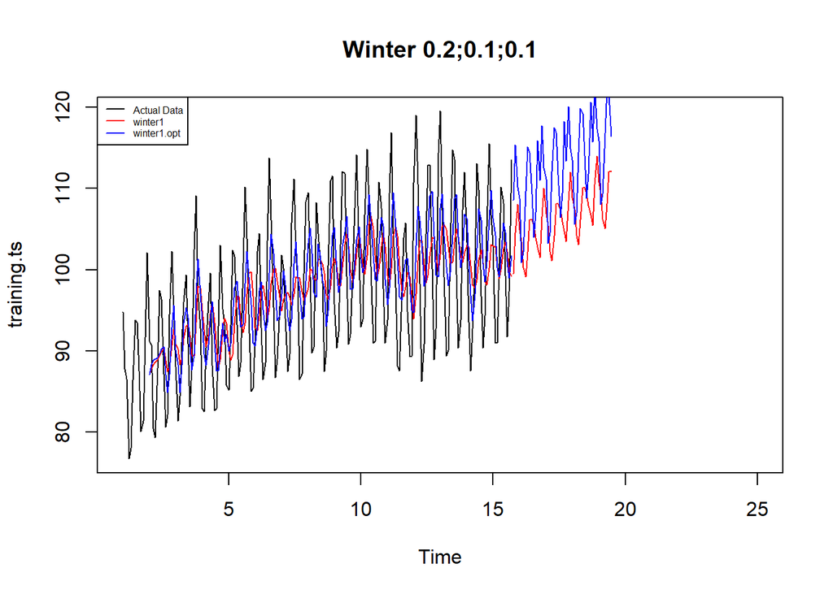

```r
#Plot time series
plot(training.ts,main="Winter 0.2;0.1;0.1",type="l",col="black",
     xlim=c(1,25),pch=12)
lines(xhat1,type="l",col="red")
lines(xhat1.opt,type="l",col="blue")
lines(forecast1,type="l",col="red")
lines(forecast1.opt,type="l",col="blue")
legend("topleft",c("Actual Data",expression(paste(winter1)),
                   expression(paste(winter1.opt))),cex=0.5,
       col=c("black","red","blue"),lty=1)
```

#### Akurasi Data Latih

```r
#Akurasi data training
SSE1<-winter1$SSE
MSE1<-winter1$SSE/length(training.ts)
RMSE1<-sqrt(MSE1)
akurasi1 <- matrix(c(SSE1,MSE1,RMSE1))
row.names(akurasi1)<- c("SSE", "MSE", "RMSE")
colnames(akurasi1) <- c("Akurasi")
akurasi1
```

```
##          Akurasi
## SSE  19249.76741
## MSE    100.25921
## RMSE    10.01295
```

```r
SSE1.opt<-winter1.opt$SSE
MSE1.opt<-winter1.opt$SSE/length(training.ts)
RMSE1.opt<-sqrt(MSE1.opt)
akurasi1.opt <- matrix(c(SSE1.opt,MSE1.opt,RMSE1.opt))
row.names(akurasi1.opt)<- c("SSE1.opt", "MSE1.opt", "RMSE1.opt")
colnames(akurasi1.opt) <- c("Akurasi")
akurasi1.opt
```

```
##                Akurasi
## SSE1.opt  13896.693461
## MSE1.opt     72.378612
## RMSE1.opt     8.507562
```

```r
akurasi1.train = data.frame(Model_Winter = c("Winter 1","Winter1 optimal"),
                            Nilai_SSE=c(SSE1,SSE1.opt),
                            Nilai_MSE=c(MSE1,MSE1.opt),Nilai_RMSE=c(RMSE1,RMSE1.opt))
akurasi1.train
```

```
##      Model_Winter Nilai_SSE Nilai_MSE Nilai_RMSE
## 1        Winter 1  19249.77 100.25921  10.012952
## 2 Winter1 optimal  13896.69  72.37861   8.507562
```

#### Akurasi Data Uji

```r
#Akurasi Data Testing
forecast1<-data.frame(forecast1)
testing.ts<-data.frame(testing.ts)
selisih1<-forecast1-testing.ts
SSEtesting1<-sum(selisih1^2)
MSEtesting1<-SSEtesting1/length(testing.ts)

forecast1.opt<-data.frame(forecast1.opt)
selisih1.opt<-forecast1.opt-testing.ts
SSEtesting1.opt<-sum(selisih1.opt^2)
MSEtesting1.opt<-SSEtesting1.opt/length(testing.ts)
```

```r
akurasi_testing <- data.frame(
  Model = c("Model1", "Model Optimum"),
  SSE   = c(SSEtesting1, SSEtesting1.opt),
  MSE   = c(MSEtesting1, MSEtesting1.opt)
)

akurasi_testing
```

```
##           Model       SSE       MSE
## 1        Model1  6589.276  6589.276
## 2 Model Optimum 11578.072 11578.072
```

### Winter Multiplikatif

Model multiplikatif digunakan cocok digunakan jika plot data asli menunjukkan fluktuasi musiman yang bervariasi.

#### Pemulusan

```r
#Pemulusan dengan winter multiplikatif
winter2 <- HoltWinters(training.ts,alpha=0.2,beta=0.1,gamma=0.3,seasonal = "multiplicative")
winter2$fitted
```

```
## Time Series:
## Start = c(2, 1)
## End = c(15, 10)
## Frequency = 13
##                xhat     level         trend    season
##  2.000000  88.53261  87.09424  0.1827109045 1.0143871
##  2.076923  89.35114  87.79949  0.2349649788 1.0149565
##  2.153846  80.24923  88.30776  0.2622954117 0.9060538
##  2.230769  79.27077  88.62929  0.2682192600 0.8917097
##  2.307692  87.01558  88.92396  0.2708642461 0.9755676
##  2.384615  96.19416  89.36447  0.2878291241 1.0729692
##  2.461538  96.06461  89.89390  0.3119889327 1.0649483
##  2.538462  96.16187  90.27182  0.3185824660 1.0615017
##  2.615385  88.25357  88.90655  0.1501970777 0.9909813
##  2.692308  79.77034  87.52036 -0.0034420368 0.9114848
##  2.769231  81.45889  88.05059  0.0499250122 0.9246131
##  2.846154  94.18287  90.92384  0.3322574326 1.0320721
##  2.923077 106.25007  92.81553  0.4882006614 1.1387548
##  3.000000  93.46197  91.20474  0.2783017380 1.0216317
##  3.076923  92.30178  90.43192  0.1731900926 1.0187259
##  3.153846  80.18948  88.47318 -0.0400032385 0.9067805
##  3.230769  79.77237  89.37403  0.0540816599 0.8920280
##  3.307692  90.21214  91.95454  0.3067245472 0.9777900
##  3.384615 101.04367  93.44425  0.4250231729 1.0764297
##  3.461538 100.14205  93.55838  0.3939339204 1.0658817
##  3.538462  95.89750  92.22149  0.2208517869 1.0373764
##  3.615385  87.26861  89.98293 -0.0250898510 0.9701057
##  3.692308  82.72934  90.11707 -0.0091659726 0.9181141
##  3.769231  90.94402  94.40508  0.4205508742 0.9590659
##  3.846154 104.66983  98.61350  0.7993377080 1.0528804
##  3.923077 109.23068  97.98853  0.6569069904 1.1073060
##  4.000000  96.75250  95.68286  0.3606495383 1.0073820
##  4.076923  92.38005  93.29629  0.0859275109 0.9892681
##  4.153846  83.81772  91.39417 -0.1128770171 0.9182354
##  4.230769  85.45819  92.71399  0.0303930079 0.9214379
##  4.307692  94.60832  95.04857  0.2608113224 0.9926444
##  4.384615 103.63941  96.30573  0.3604457716 1.0721373
##  4.461538  97.80625  93.80116  0.0739449194 1.0418763
##  4.538462  91.06052  90.97260 -0.2163054328 1.0033521
##  4.615385  86.28690  89.13601 -0.3783346868 0.9721627
```

[output cut: 129 more lines]

```
## 14.615385 101.96682 102.13055 -0.0001936158 0.9983987
## 14.692308  95.81515  99.80938 -0.2322916359 0.9622209
## 14.769231  93.46126  99.27083 -0.2629176749 0.9439777
## 14.846154 100.25923 101.51029 -0.0126798894 0.9877989
## 14.923077 107.87566 104.58361  0.2959208571 1.0285673
## 15.000000 107.87494 104.65754  0.2737217585 1.0280533
## 15.076923 104.20359 103.98187  0.1787823748 1.0004122
## 15.153846  98.59750 101.52286 -0.0849966184 0.9719989
## 15.230769  94.72519  99.86706 -0.2420769598 0.9508176
## 15.307692  96.92941 100.88085 -0.1164901618 0.9619414
## 15.384615 104.74592 103.51268  0.1583413438 1.0103683
## 15.461538 107.10612 104.34992  0.2262311270 1.0241926
## 15.538462 103.07030 103.04807  0.0734236000 0.9995035
## 15.615385  97.74427 100.86374 -0.1523525163 0.9705384
## 15.692308  96.30204 100.61680 -0.1618105752 0.9586586
```

```r
xhat2 <- winter2$fitted[,2]

winter2.opt<- HoltWinters(training.ts, alpha= NULL,  beta = NULL, gamma = NULL, seasonal = "multiplicative")
winter2.opt$fitted
```

```
## Time Series:
## Start = c(2, 1)
## End = c(15, 10)
## Frequency = 13
##                xhat     level     trend    season
##  2.000000  88.53261  87.09424 0.1827109 1.0143871
##  2.076923  89.85599  88.34915 0.1827109 1.0149565
##  2.153846  80.70334  88.88853 0.1827109 0.9060538
##  2.230769  79.51360  88.98712 0.1827109 0.8917097
##  2.307692  87.11336  89.11235 0.1827109 0.9755676
##  2.384615  96.33626  89.60203 0.1827109 1.0729692
##  2.461538  96.28074  90.22613 0.1827109 1.0649483
##  2.538462  96.21829  90.46084 0.1827109 1.0615017
##  2.615385  86.56156  87.16663 0.1827109 0.9909813
##  2.692308  77.54931  84.89750 0.1827109 0.9114848
##  2.769231  80.77230  87.17523 0.1827109 0.9246131
##  2.846154  96.64178  93.45588 0.1827109 1.0320721
##  2.923077 109.36987  95.86067 0.1827109 1.1387548
##  3.000000  93.70705  90.61214 0.1827109 1.0320744
##  3.076923  90.59173  88.56243 0.1827109 1.0208077
##  3.153846  77.13591  85.06700 0.1827109 0.9048231
##  3.230769  79.06775  88.56937 0.1827109 0.8908833
##  3.307692  92.59594  94.26733 0.1827109 0.9803696
##  3.384615 103.78942  95.87317 0.1827109 1.0805108
##  3.461538 100.78495  94.37753 0.1827109 1.0658280
##  3.538462  91.00444  90.76103 0.1827109 1.0006674
##  3.615385  83.49430  87.71880 0.1827109 0.9498619
##  3.692308  84.91196  89.86589 0.1827109 0.9429571
##  3.769231  98.97174  97.68380 0.1827109 1.0112932
##  3.846154 108.95070 101.97984 0.1827109 1.0664446
##  3.923077 101.79227  97.62984 0.1827109 1.0406872
##  4.000000  93.95942  94.27772 0.1827109 0.9946960
##  4.076923  86.24818  89.90384 0.1827109 0.9573924
##  4.153846  84.56313  88.49984 0.1827109 0.9535486
##  4.230769  88.24762  91.19265 0.1827109 0.9657705
##  4.307692  95.00497  94.70100 0.1827109 1.0012780
##  4.384615 102.05857  96.74792 0.1827109 1.0529032
##  4.461538  91.90183  91.56065 0.1827109 1.0017272
##  4.538462  83.55005  87.96788 0.1827109 0.9478105
##  4.615385  86.27732  87.88294 0.1827109 0.9796932
```

[output cut: 129 more lines]

```
## 14.615385  96.88938 103.59658 0.1827109 0.9336100
## 14.692308  89.33367 100.91822 0.1827109 0.8836088
## 14.769231  93.28991 103.42685 0.1827109 0.9003986
## 14.846154 107.07768 109.07083 0.1827109 0.9800843
## 14.923077 115.99251 112.78056 0.1827109 1.0268161
## 15.000000 108.68158 109.26298 0.1827109 0.9930184
## 15.076923 100.70952 107.09553 0.1827109 0.9387693
## 15.153846  93.93569 103.03776 0.1827109 0.9100491
## 15.230769  95.13584 101.88013 0.1827109 0.9321301
## 15.307692 100.13873 104.51063 0.1827109 0.9564956
## 15.384615 111.50513 108.98780 0.1827109 1.0213851
## 15.461538 108.70123 107.83274 0.1827109 1.0063489
## 15.538462  97.45285 104.17391 0.1827109 0.9338445
## 15.615385  91.39364 101.86678 0.1827109 0.8955816
## 15.692308  95.71457 104.74922 0.1827109 0.9121587
```

```r
xhat2.opt <- winter2.opt$fitted[,2]
```

#### Peramalan

```r
#Forecast
forecast2 <- predict(winter2, n.ahead = 49)
forecast2.opt <- predict(winter2.opt, n.ahead = 49)
```

#### Plot Deret Waktu

[figure not shown]

```r
#Plot time series
plot(training.ts,main="Winter 0.2;0.1;0.1",type="l",col="black",
     xlim=c(1,25),pch=12)
lines(xhat2,type="l",col="red")
lines(xhat2.opt,type="l",col="blue")
lines(forecast2,type="l",col="red")
lines(forecast2.opt,type="l",col="blue")
legend("topleft",c("Actual Data",expression(paste(winter2)),
                   expression(paste(winter2.opt))),cex=0.5,
       col=c("black","red","blue"),lty=1)
```

#### Akurasi Data Latih

```r
#Akurasi data training
SSE2<-winter2$SSE
MSE2<-winter2$SSE/length(training.ts)
RMSE2<-sqrt(MSE2)
akurasi1 <- matrix(c(SSE2,MSE2,RMSE2))
row.names(akurasi1)<- c("SSE2", "MSE2", "RMSE2")
colnames(akurasi1) <- c("Akurasi lamda=0.2")
akurasi1
```

```
##       Akurasi lamda=0.2
## SSE2       18378.242877
## MSE2          95.720015
## RMSE2          9.783661
```

```r
SSE2.opt<-winter2.opt$SSE
MSE2.opt<-winter2.opt$SSE/length(training.ts)
RMSE2.opt<-sqrt(MSE2.opt)
akurasi1.opt <- matrix(c(SSE2.opt,MSE2.opt,RMSE2.opt))
row.names(akurasi1.opt)<- c("SSE2.opt", "MSE2.opt", "RMSE2.opt")
colnames(akurasi1.opt) <- c("Akurasi")
akurasi1.opt
```

```
##                Akurasi
## SSE2.opt  14014.482201
## MSE2.opt     72.992095
## RMSE2.opt     8.543541
```

```r
akurasi2.train = data.frame(Model_Winter = c("Winter 1","winter2 optimal"),
                            Nilai_SSE=c(SSE2,SSE2.opt),
                            Nilai_MSE=c(MSE2,MSE2.opt),Nilai_RMSE=c(RMSE2,RMSE2.opt))
akurasi2.train
```

```
##      Model_Winter Nilai_SSE Nilai_MSE Nilai_RMSE
## 1        Winter 1  18378.24  95.72001   9.783661
## 2 winter2 optimal  14014.48  72.99209   8.543541
```

#### Akurasi Data Uji

```r
#Akurasi Data Testing
# Pastikan forecast2 dan testing.ts dalam bentuk data.frame
forecast2 <- data.frame(forecast2)
testing.ts <- data.frame(testing.ts)

# Samakan panjangnya (ambil baris minimum dari keduanya)
n <- min(nrow(forecast2), nrow(testing.ts))

# Hitung selisih antar nilai prediksi dan aktual
selisih2 <- forecast2[1:n, 1] - testing.ts[1:n, 1]

# Hitung SSE & MSE
SSEtesting2 <- sum(selisih2^2)
MSEtesting2 <- SSEtesting2 / n

# Ulangi proses untuk forecast2.opt
forecast2.opt <- data.frame(forecast2.opt)
selisih2.opt <- forecast2.opt[1:n, 1] - testing.ts[1:n, 1]

SSEtesting2.opt <- sum(selisih2.opt^2)
MSEtesting2.opt <- SSEtesting2.opt / n
```

```r
SSEtesting2.opt
```

```
## [1] 12039.46
```

```r
MSEtesting2.opt
```

```
## [1] 245.7033
```

```r
# Atau rapikan dalam tabel
akurasi_testing2 <- data.frame(
  Model = c("Model2", "Model2 Optimal"),
  SSE   = c(SSEtesting2, SSEtesting2.opt),
  MSE   = c(MSEtesting2, MSEtesting2.opt))
View(akurasi_testing2)
```

SMA

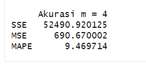

DMA

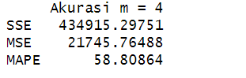

SES

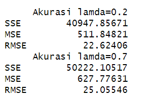

SES

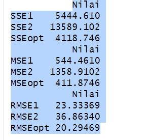